# Identifying Risk Factors and Preferred Hospitals for Hip/Knee Replacements: An Analysis of 2019-2022 Hospital Readmission Reduction Program Data

#### Reassess collinearity with heatmap and correlation matrix

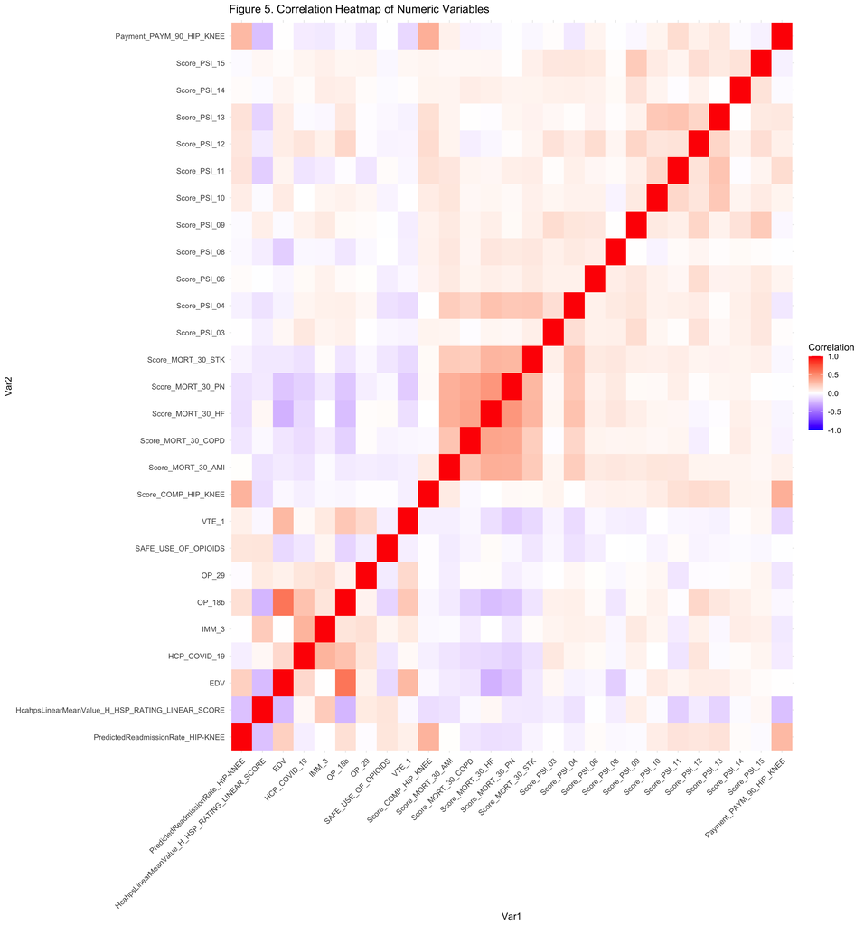

```r
# Compute correlation matrix
cor_matrix <- cor(HipKneeTrain %>% select_if(is.numeric), use = "pairwise.complete.obs")

# Melt the correlation matrix into a long format
cor_melted <- melt(cor_matrix)

# Plot heatmap
ggplot(cor_melted, aes(x = Var1, y = Var2, fill = value)) +
  geom_tile() +
  scale_fill_gradient2(low = "blue", high = "red", mid = "white",
                       midpoint = 0, limit = c(-1, 1), name = "Correlation") +
  theme_minimal() +
  theme(axis.text.x = element_text(angle = 45, hjust = 1)) +
  labs(title = "Figure 5. Correlation Heatmap of Numeric Variables")
```

```r
# Convert correlation matrix to df
cor_table <- as.data.frame(cor_matrix)

# Add variable names as a column
cor_table$Variable <- rownames(cor_table)

# Reorder columns
cor_table <- cor_table %>%
  select(Variable, everything())

# Print table
cor_table %>%
  kable(caption = "Table 8. Correlation Coefficients Table") %>%
  kable_styling(bootstrap_options = c("hover", "striped", "responsive"))
```

Table 8. Correlation Coefficients Table

|  | Variable | PredictedReadmissionRate_HIP-KNEE | HcahpsLinearMeanValue_H_HSP_RATING_LINEAR_SCORE | EDV | HCP_COVID_19 | IMM_3 | OP_18b | OP_29 | SAFE_USE_OF_OPIOIDS | VTE_1 | Score_COMP_HIP_KNEE | Score_MORT_30_AMI | Score_MORT_30_COPD | Score_MORT_30_HF | Score_MORT_30_PN | Score_MORT_30_STK | Score_PSI_03 | Score_PSI_04 | Score_PSI_06 | Score_PSI_08 | Score_PSI_09 | Score_PSI_10 | Score_PSI_11 | Score_PSI_12 | Score_PSI_13 | Score_PSI_14 | Score_PSI_15 | Payment_PAYM_90_HIP_KNEE |
| --- | --- | --- | --- | --- | --- | --- | --- | --- | --- | --- | --- | --- | --- | --- | --- | --- | --- | --- | --- | --- | --- | --- | --- | --- | --- | --- | --- | --- |
| PredictedReadmissionRate_HIP-KNEE | PredictedReadmissionRate_HIP-KNEE | 1.0000000 | -0.2060912 | 0.1986939 | -0.0563082 | -0.0028840 | 0.1295727 | -0.0106510 | 0.1063002 | 0.0654668 | 0.3208550 | 0.0074065 | -0.0794948 | -0.1067828 | -0.0985660 | -0.0376746 | -0.0037334 | -0.0449077 | 0.0154891 | -0.0214412 | -0.0182303 | 0.0710046 | 0.1130121 | 0.1047402 | 0.1193336 | 0.0140012 | -0.0158282 | 0.2975679 |
| HcahpsLinearMeanValue_H_HSP_RATING_LINEAR_SCORE | HcahpsLinearMeanValue_H_HSP_RATING_LINEAR_SCORE | -0.2060912 | 1.0000000 | -0.2262341 | 0.0302154 | 0.2182505 | -0.2448842 | 0.0865028 | 0.1100002 | -0.0248375 | -0.1091775 | -0.0952111 | -0.0230632 | 0.0300940 | -0.0702915 | -0.0760295 | -0.0499063 | -0.0948401 | -0.0054742 | -0.0590998 | 0.0707774 | -0.0157615 | -0.1615833 | -0.0674588 | -0.1458284 | -0.0172231 | 0.0304634 | -0.2108956 |
| EDV | EDV | 0.1986939 | -0.2262341 | 1.0000000 | 0.1599806 | 0.0038674 | 0.5918897 | 0.0603877 | -0.1223889 | 0.2992859 | -0.0240093 | -0.0687401 | -0.0840621 | -0.2588739 | -0.1904351 | -0.0754281 | 0.0292819 | -0.0438108 | -0.0308989 | -0.1637017 | -0.0181523 | 0.0837980 | 0.0455190 | 0.0749218 | 0.0724936 | 0.0399935 | 0.0144400 | 0.0053946 |
| HCP_COVID_19 | HCP_COVID_19 | -0.0563082 | 0.0302154 | 0.1599806 | 1.0000000 | 0.3203622 | 0.2574291 | 0.1067941 | -0.0812735 | 0.0241622 | -0.0510683 | -0.0869890 | -0.1128278 | -0.1245435 | -0.1523779 | -0.0988833 | 0.0943953 | 0.0417007 | 0.0225916 | -0.0272232 | 0.0549990 | 0.0009222 | -0.0909811 | 0.1091949 | -0.0160408 | 0.0169512 | 0.0430812 | -0.0627505 |
| IMM_3 | IMM_3 | -0.0028840 | 0.2182505 | 0.0038674 | 0.3203622 | 1.0000000 | 0.1105628 | 0.1317922 | 0.0410289 | 0.0906329 | -0.0212916 | -0.0165321 | -0.0616051 | -0.0010634 | -0.0761104 | 0.0146397 | 0.0451508 | 0.0601831 | 0.0544576 | -0.0311579 | 0.0899361 | 0.0412713 | -0.0625676 | 0.0594933 | -0.0250714 | 0.0723872 | 0.0625753 | -0.0720431 |
| OP_18b | OP_18b | 0.1295727 | -0.2448842 | 0.5918897 | 0.2574291 | 0.1105628 | 1.0000000 | 0.0506067 | -0.1400845 | 0.2344307 | -0.0293698 | -0.0678837 | -0.1527290 | -0.2195933 | -0.1858291 | -0.0905644 | 0.0583644 | 0.0638412 | 0.0187794 | -0.0806516 | 0.0224833 | 0.0544528 | -0.0076797 | 0.1653812 | 0.0993570 | 0.0676972 | 0.0374530 | -0.0241965 |
| OP_29 | OP_29 | -0.0106510 | 0.0865028 | 0.0603877 | 0.1067941 | 0.1317922 | 0.0506067 | 1.0000000 | -0.0650231 | 0.1567526 | -0.0096464 | -0.0600569 | 0.0081252 | 0.0099705 | -0.0536184 | -0.0251654 | -0.0032584 | 0.0312780 | 0.0059688 | -0.0199006 | 0.0150699 | 0.0331569 | -0.0837910 | -0.0108546 | -0.0087678 | 0.0163779 | 0.0419068 | -0.0815209 |
| SAFE_USE_OF_OPIOIDS | SAFE_USE_OF_OPIOIDS | 0.1063002 | 0.1100002 | -0.1223889 | -0.0812735 | 0.0410289 | -0.1400845 | -0.0650231 | 1.0000000 | -0.0563373 | -0.0081923 | -0.0643353 | -0.0362573 | 0.0171605 | -0.0204107 | -0.0804707 | -0.0287158 | -0.0995591 | -0.0603629 | -0.0017558 | -0.0043396 | -0.0382369 | 0.0137283 | -0.0380145 | -0.0258097 | -0.0166146 | -0.0268805 | -0.0048449 |
| VTE_1 | VTE_1 | 0.0654668 | -0.0248375 | 0.2992859 | 0.0241622 | 0.0906329 | 0.2344307 | 0.1567526 | -0.0563373 | 1.0000000 | -0.0526925 | -0.0493931 | -0.0282911 | -0.1051171 | -0.1710235 | -0.1238916 | -0.0378500 | -0.1180160 | -0.0262166 | -0.0522876 | -0.0577213 | -0.0037803 | -0.0301775 | -0.0317534 | -0.0440578 | 0.0086141 | 0.0326658 | -0.1256363 |
| Score_COMP_HIP_KNEE | Score_COMP_HIP_KNEE | 0.3208550 | -0.1091775 | -0.0240093 | -0.0510683 | -0.0212916 | -0.0293698 | -0.0096464 | -0.0081923 | -0.0526925 | 1.0000000 | 0.0830479 | -0.0203930 | -0.0007242 | 0.0241066 | 0.0211621 | 0.0498557 | 0.0038509 | 0.0505415 | 0.0577776 | 0.0540124 | 0.0813038 | 0.1279724 | 0.1458258 | 0.1334619 | 0.0498603 | 0.0433809 | 0.3410864 |
| Score_MORT_30_AMI | Score_MORT_30_AMI | 0.0074065 | -0.0952111 | -0.0687401 | -0.0869890 | -0.0165321 | -0.0678837 | -0.0600569 | -0.0643353 | -0.0493931 | 0.0830479 | 1.0000000 | 0.2498600 | 0.3407616 | 0.3309425 | 0.2222539 | 0.0415523 | 0.2105379 | 0.0885083 | 0.1010348 | 0.0889343 | 0.1066619 | 0.1037006 | 0.0492328 | 0.0467554 | 0.0454462 | 0.0297688 | 0.0591548 |
| Score_MORT_30_COPD | Score_MORT_30_COPD | -0.0794948 | -0.0230632 | -0.0840621 | -0.1128278 | -0.0616051 | -0.1527290 | 0.0081252 | -0.0362573 | -0.0282911 | -0.0203930 | 0.2498600 | 1.0000000 | 0.3844105 | 0.3710744 | 0.2038243 | -0.0069743 | 0.1713379 | 0.0478268 | 0.0397571 | 0.0429090 | 0.0320669 | 0.0426574 | -0.0532586 | 0.0026944 | 0.0734846 | 0.0340007 | -0.0406696 |
| Score_MORT_30_HF | Score_MORT_30_HF | -0.1067828 | 0.0300940 | -0.2588739 | -0.1245435 | -0.0010634 | -0.2195933 | 0.0099705 | 0.0171605 | -0.1051171 | -0.0007242 | 0.3407616 | 0.3844105 | 1.0000000 | 0.4479367 | 0.3147371 | 0.0371596 | 0.2556384 | 0.0679149 | 0.1051698 | 0.0707269 | 0.0383771 | 0.0362529 | -0.0300702 | -0.0086832 | 0.0647245 | 0.0342374 | -0.0350247 |
| Score_MORT_30_PN | Score_MORT_30_PN | -0.0985660 | -0.0702915 | -0.1904351 | -0.1523779 | -0.0761104 | -0.1858291 | -0.0536184 | -0.0204107 | -0.1710235 | 0.0241066 | 0.3309425 | 0.3710744 | 0.4479367 | 1.0000000 | 0.3042563 | 0.0303815 | 0.2301195 | 0.0543554 | 0.0884315 | 0.0217880 | 0.0237048 | 0.0704445 | 0.0089560 | 0.0393676 | 0.0464407 | 0.0029691 | -0.0062985 |
| Score_MORT_30_STK | Score_MORT_30_STK | -0.0376746 | -0.0760295 | -0.0754281 | -0.0988833 | 0.0146397 | -0.0905644 | -0.0251654 | -0.0804707 | -0.1238916 | 0.0211621 | 0.2222539 | 0.2038243 | 0.3147371 | 0.3042563 | 1.0000000 | 0.0687216 | 0.2380935 | 0.0878847 | 0.1014879 | 0.0674377 | 0.0622532 | 0.0725381 | 0.0474896 | 0.0513975 | 0.0492194 | 0.0625191 | -0.0272101 |
| Score_PSI_03 | Score_PSI_03 | -0.0037334 | -0.0499063 | 0.0292819 | 0.0943953 | 0.0451508 | 0.0583644 | -0.0032584 | -0.0287158 | -0.0378500 | 0.0498557 | 0.0415523 | -0.0069743 | 0.0371596 | 0.0303815 | 0.0687216 | 1.0000000 | 0.1353085 | 0.0601750 | 0.0636661 | 0.1407342 | 0.0386211 | 0.0114365 | 0.1186788 | 0.0298580 | 0.0596798 | 0.0999683 | 0.0086745 |
| Score_PSI_04 | Score_PSI_04 | -0.0449077 | -0.0948401 | -0.0438108 | 0.0417007 | 0.0601831 | 0.0638412 | 0.0312780 | -0.0995591 | -0.1180160 | 0.0038509 | 0.2105379 | 0.1713379 | 0.2556384 | 0.2301195 | 0.2380935 | 0.1353085 | 1.0000000 | 0.0601419 | 0.0870693 | 0.1059485 | 0.0523892 | 0.0649032 | 0.0782559 | 0.0123489 | 0.0652098 | 0.1018205 | -0.0766302 |
| Score_PSI_06 | Score_PSI_06 | 0.0154891 | -0.0054742 | -0.0308989 | 0.0225916 | 0.0544576 | 0.0187794 | 0.0059688 | -0.0603629 | -0.0262166 | 0.0505415 | 0.0885083 | 0.0478268 | 0.0679149 | 0.0543554 | 0.0878847 | 0.0601750 | 0.0601419 | 1.0000000 | 0.0724291 | 0.1014588 | 0.0516246 | 0.0351464 | 0.1431056 | 0.0509831 | 0.0527115 | 0.0910520 | 0.0456525 |
| Score_PSI_08 | Score_PSI_08 | -0.0214412 | -0.0590998 | -0.1637017 | -0.0272232 | -0.0311579 | -0.0806516 | -0.0199006 | -0.0017558 | -0.0522876 | 0.0577776 | 0.1010348 | 0.0397571 | 0.1051698 | 0.0884315 | 0.1014879 | 0.0636661 | 0.0870693 | 0.0724291 | 1.0000000 | 0.0052449 | -0.0360093 | 0.0198090 | 0.0394605 | 0.0093444 | 0.0228045 | 0.0127268 | -0.0041983 |
| Score_PSI_09 | Score_PSI_09 | -0.0182303 | 0.0707774 | -0.0181523 | 0.0549990 | 0.0899361 | 0.0224833 | 0.0150699 | -0.0043396 | -0.0577213 | 0.0540124 | 0.0889343 | 0.0429090 | 0.0707269 | 0.0217880 | 0.0674377 | 0.1407342 | 0.1059485 | 0.1014588 | 0.0052449 | 1.0000000 | 0.0885278 | 0.0680540 | 0.1732337 | 0.0519119 | 0.1207438 | 0.2197254 | -0.0237660 |
| Score_PSI_10 | Score_PSI_10 | 0.0710046 | -0.0157615 | 0.0837980 | 0.0009222 | 0.0412713 | 0.0544528 | 0.0331569 | -0.0382369 | -0.0037803 | 0.0813038 | 0.1066619 | 0.0320669 | 0.0383771 | 0.0237048 | 0.0622532 | 0.0386211 | 0.0523892 | 0.0516246 | -0.0360093 | 0.0885278 | 1.0000000 | 0.1626632 | 0.1079488 | 0.2303938 | 0.0453739 | 0.0830134 | 0.0497447 |
| Score_PSI_11 | Score_PSI_11 | 0.1130121 | -0.1615833 | 0.0455190 | -0.0909811 | -0.0625676 | -0.0076797 | -0.0837910 | 0.0137283 | -0.0301775 | 0.1279724 | 0.1037006 | 0.0426574 | 0.0362529 | 0.0704445 | 0.0725381 | 0.0114365 | 0.0649032 | 0.0351464 | 0.0198090 | 0.0680540 | 0.1626632 | 1.0000000 | 0.1172504 | 0.2506376 | -0.0093577 | 0.0464067 | 0.1441986 |
| Score_PSI_12 | Score_PSI_12 | 0.1047402 | -0.0674588 | 0.0749218 | 0.1091949 | 0.0594933 | 0.1653812 | -0.0108546 | -0.0380145 | -0.0317534 | 0.1458258 | 0.0492328 | -0.0532586 | -0.0300702 | 0.0089560 | 0.0474896 | 0.1186788 | 0.0782559 | 0.1431056 | 0.0394605 | 0.1732337 | 0.1079488 | 0.1172504 | 1.0000000 | 0.1742084 | 0.0522204 | 0.1358951 | 0.0655557 |
| Score_PSI_13 | Score_PSI_13 | 0.1193336 | -0.1458284 | 0.0724936 | -0.0160408 | -0.0250714 | 0.0993570 | -0.0087678 | -0.0258097 | -0.0440578 | 0.1334619 | 0.0467554 | 0.0026944 | -0.0086832 | 0.0393676 | 0.0513975 | 0.0298580 | 0.0123489 | 0.0509831 | 0.0093444 | 0.0519119 | 0.2303938 | 0.2506376 | 0.1742084 | 1.0000000 | 0.0056987 | 0.0878105 | 0.0949467 |
| Score_PSI_14 | Score_PSI_14 | 0.0140012 | -0.0172231 | 0.0399935 | 0.0169512 | 0.0723872 | 0.0676972 | 0.0163779 | -0.0166146 | 0.0086141 | 0.0498603 | 0.0454462 | 0.0734846 | 0.0647245 | 0.0464407 | 0.0492194 | 0.0596798 | 0.0652098 | 0.0527115 | 0.0228045 | 0.1207438 | 0.0453739 | -0.0093577 | 0.0522204 | 0.0056987 | 1.0000000 | 0.1176726 | -0.0181150 |
| Score_PSI_15 | Score_PSI_15 | -0.0158282 | 0.0304634 | 0.0144400 | 0.0430812 | 0.0625753 | 0.0374530 | 0.0419068 | -0.0268805 | 0.0326658 | 0.0433809 | 0.0297688 | 0.0340007 | 0.0342374 | 0.0029691 | 0.0625191 | 0.0999683 | 0.1018205 | 0.0910520 | 0.0127268 | 0.2197254 | 0.0830134 | 0.0464067 | 0.1358951 | 0.0878105 | 0.1176726 | 1.0000000 | -0.0467071 |
| Payment_PAYM_90_HIP_KNEE | Payment_PAYM_90_HIP_KNEE | 0.2975679 | -0.2108956 | 0.0053946 | -0.0627505 | -0.0720431 | -0.0241965 | -0.0815209 | -0.0048449 | -0.1256363 | 0.3410864 | 0.0591548 | -0.0406696 | -0.0350247 | -0.0062985 | -0.0272101 | 0.0086745 | -0.0766302 | 0.0456525 | -0.0041983 | -0.0237660 | 0.0497447 | 0.1441986 | 0.0655557 | 0.0949467 | -0.0181150 | -0.0467071 | 1.0000000 |

## Imputation and Handling of Missing Values (AC)

```r
# Change - to _ in HIP-KNEE
colnames(HipKneeTrain) <- gsub("-", "_", colnames(HipKneeTrain))

# Remove all NA values in target variable "PredictedReadmissionRate_HIP_KNEE"
HipKneeTrain <- HipKneeTrain %>% filter(!is.na(PredictedReadmissionRate_HIP_KNEE))

# Remove all NA values in the "State", "StateCode", and "FacilityName" columns
HipKneeTrain <- HipKneeTrain %>% drop_na(State, StateCode, FacilityName)


# Print number of remaining variables and observations
dimensions <- dim(HipKneeTrain)
cat("Number of variables:", dimensions[2], "\n")
```

```
## Number of variables: 31
```

```r
cat("Number of observations:", dimensions[1], "\n")
```

```
## Number of observations: 1833
```

> We decided to remove the one facility that had an NA value, which also happened to be the same observation with a missing state value.

```r
# Calculate missing values
missing_values_summary <- HipKneeTrain %>%
  summarise(across(everything(), ~ sum(is.na(.)))) %>%
  pivot_longer(cols = everything(), names_to = "Variable", values_to = "Missing_Count") %>%
  mutate(Missing_Percentage = (Missing_Count / nrow(HipKneeTrain)) * 100)

# Print table
missing_values_summary %>%
  kable(caption = "Table 7. Missing Values Summary") %>%
  kable_styling(bootstrap_options = c("hover", "striped", "responsive"))
```

Table 7. Missing Values Summary

| Variable | Missing_Count | Missing_Percentage |
| --- | --- | --- |
| FacilityId | 0 | 0.0000000 |
| PredictedReadmissionRate_HIP_KNEE | 0 | 0.0000000 |
| HcahpsLinearMeanValue_H_HSP_RATING_LINEAR_SCORE | 33 | 1.8003273 |
| EDV | 90 | 4.9099836 |
| HCP_COVID_19 | 16 | 0.8728860 |
| IMM_3 | 16 | 0.8728860 |
| OP_18b | 75 | 4.0916530 |
| OP_29 | 222 | 12.1112930 |
| SAFE_USE_OF_OPIOIDS | 69 | 3.7643208 |
| VTE_1 | 994 | 54.2280415 |
| Score_COMP_HIP_KNEE | 40 | 2.1822149 |
| Score_MORT_30_AMI | 405 | 22.0949264 |
| Score_MORT_30_COPD | 247 | 13.4751773 |
| Score_MORT_30_HF | 141 | 7.6923077 |
| Score_MORT_30_PN | 125 | 6.8194217 |
| Score_MORT_30_STK | 284 | 15.4937261 |
| Score_PSI_03 | 8 | 0.4364430 |
| Score_PSI_04 | 575 | 31.3693399 |
| Score_PSI_06 | 2 | 0.1091107 |
| Score_PSI_08 | 2 | 0.1091107 |
| Score_PSI_09 | 2 | 0.1091107 |
| Score_PSI_10 | 41 | 2.2367703 |
| Score_PSI_11 | 40 | 2.1822149 |
| Score_PSI_12 | 2 | 0.1091107 |
| Score_PSI_13 | 42 | 2.2913257 |
| Score_PSI_14 | 87 | 4.7463175 |
| Score_PSI_15 | 29 | 1.5821058 |
| FacilityName | 0 | 0.0000000 |
| State | 0 | 0.0000000 |
| Payment_PAYM_90_HIP_KNEE | 42 | 2.2913257 |
| StateCode | 0 | 0.0000000 |

#### Impute variables with low percentage missingness (<5%) by the median for numeric variables and mode for categorical variables

```r
# Calculate median for columns with <5% missing values
numeric_vars_low_missing <- c("HcahpsLinearMeanValue_H_HSP_RATING_LINEAR_SCORE", "EDV", "HCP_COVID_19", "IMM_3", "OP_18b", "SAFE_USE_OF_OPIOIDS", "Score_COMP_HIP_KNEE", "Score_PSI_03", "Score_PSI_06", "Score_PSI_08", "Score_PSI_09", "Score_PSI_10", "Score_PSI_11", "Score_PSI_12", "Score_PSI_13", "Score_PSI_14", "Score_PSI_15", "Payment_PAYM_90_HIP_KNEE")

for (var in numeric_vars_low_missing) {
  HipKneeTrain[[var]][is.na(HipKneeTrain[[var]])] <- median(HipKneeTrain[[var]], na.rm = TRUE)
}
```

#### Impute high percentage missingness variables (>5%) using KNN

```r
# Select high missingness variables for KNN imputation
vars_for_knn <- c("VTE_1", "Score_MORT_30_AMI", "Score_MORT_30_COPD", "Score_MORT_30_HF", "Score_MORT_30_PN", "Score_MORT_30_STK", "Score_PSI_04", "OP_29")

# Perform KNN imputation
HipKneeTrain_knn <- kNN(HipKneeTrain, variable = vars_for_knn, k = 5)

# Remove columns created by the KNN function
HipKneeTrain_knn <- HipKneeTrain_knn %>% select(-ends_with("_imp"))

# Update HipKneeTrain with imputed values
HipKneeTrain[vars_for_knn] <- HipKneeTrain_knn[vars_for_knn]
```

```r
# Calculate missing values
missing_values_summary <- HipKneeTrain %>%
  summarise(across(everything(), ~ sum(is.na(.)))) %>%
  pivot_longer(cols = everything(), names_to = "Variable", values_to = "Missing_Count") %>%
  mutate(Missing_Percentage = (Missing_Count / nrow(HipKneeTrain)) * 100)

# Print table
missing_values_summary %>%
  kable(caption = "Table 7. Missing Values Summary") %>%
  kable_styling(bootstrap_options = c("hover", "striped", "responsive"))
```

Table 7. Missing Values Summary

| Variable | Missing_Count | Missing_Percentage |
| --- | --- | --- |
| FacilityId | 0 | 0 |
| PredictedReadmissionRate_HIP_KNEE | 0 | 0 |
| HcahpsLinearMeanValue_H_HSP_RATING_LINEAR_SCORE | 0 | 0 |
| EDV | 0 | 0 |
| HCP_COVID_19 | 0 | 0 |
| IMM_3 | 0 | 0 |
| OP_18b | 0 | 0 |
| OP_29 | 0 | 0 |
| SAFE_USE_OF_OPIOIDS | 0 | 0 |
| VTE_1 | 0 | 0 |
| Score_COMP_HIP_KNEE | 0 | 0 |
| Score_MORT_30_AMI | 0 | 0 |
| Score_MORT_30_COPD | 0 | 0 |
| Score_MORT_30_HF | 0 | 0 |
| Score_MORT_30_PN | 0 | 0 |
| Score_MORT_30_STK | 0 | 0 |
| Score_PSI_03 | 0 | 0 |
| Score_PSI_04 | 0 | 0 |
| Score_PSI_06 | 0 | 0 |
| Score_PSI_08 | 0 | 0 |
| Score_PSI_09 | 0 | 0 |
| Score_PSI_10 | 0 | 0 |
| Score_PSI_11 | 0 | 0 |
| Score_PSI_12 | 0 | 0 |
| Score_PSI_13 | 0 | 0 |
| Score_PSI_14 | 0 | 0 |
| Score_PSI_15 | 0 | 0 |
| FacilityName | 0 | 0 |
| State | 0 | 0 |
| Payment_PAYM_90_HIP_KNEE | 0 | 0 |
| StateCode | 0 | 0 |

## Feature Engineer Mortality Data (AC)

```r
# Average death rates amongst mortality variables and create new column "Score_Ovr_MORT"
HipKneeTrain$Score_Ovr_MORT <- rowMeans(HipKneeTrain[, c("Score_MORT_30_AMI",
                                                         "Score_MORT_30_COPD",
                                                         "Score_MORT_30_HF",
                                                         "Score_MORT_30_PN",
                                                         "Score_MORT_30_STK")],
                                                          na.rm = TRUE)

# Remove old mortality columns
HipKneeTrain <- HipKneeTrain[, !(names(HipKneeTrain) %in% c("Score_MORT_30_AMI",
                                                            "Score_MORT_30_COPD",
                                                            "Score_MORT_30_HF",
                                                            "Score_MORT_30_PN",
                                                            "Score_MORT_30_STK"))]
```

#### Reassess heatmap with engineered mortality data

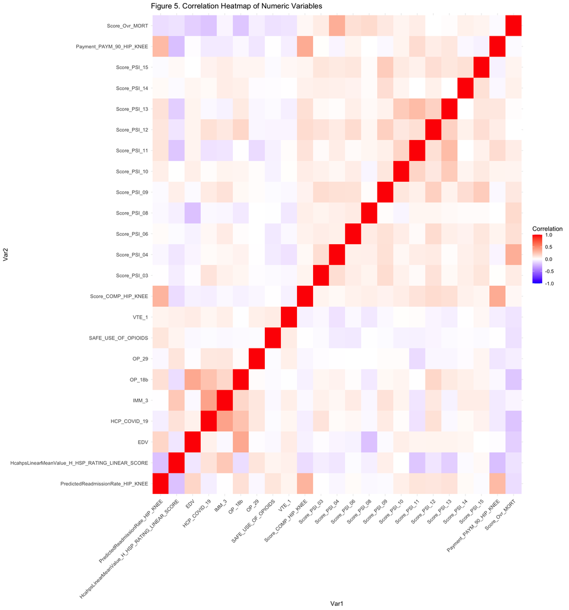

```r
# Compute correlation matrix
cor_matrix <- cor(HipKneeTrain %>% select_if(is.numeric), use = "pairwise.complete.obs")

# Melt the correlation matrix into a long format
cor_melted <- melt(cor_matrix)

# Plot heatmap
ggplot(cor_melted, aes(x = Var1, y = Var2, fill = value)) +
  geom_tile() +
  scale_fill_gradient2(low = "blue", high = "red", mid = "white",
                       midpoint = 0, limit = c(-1, 1), name = "Correlation") +
  theme_minimal() +
  theme(axis.text.x = element_text(angle = 45, hjust = 1)) +
  labs(title = "Figure 5. Correlation Heatmap of Numeric Variables")
```

#### Save the data for future ease of use

```r
save(HipKneeTrain, file = "HipKneeTrain.RData")
```

## Preprocessing the test dataset (AC)

We are utilizing the most recent snapshot from 04/24/2024 as our test set. Utilizing this brand new data will help to ensure that our model is generalizable and useful for future analyses.

### Loading the Data

```r
# Set the directory for the data files
filepath <- "/Users/adelinecasali/Desktop/hospitals_04_2024/"

# List the files in the directory that have "Hospital.csv"
files <- list.files(path = filepath, pattern = "Hospital.csv")

# Iterate through each file in the list
for(f in 1:length(files)) {

# Read the CSV, clean column names to upper camel case, and store in "dat"
    dat <- clean_names(read_csv(paste0(filepath, files[f]),
                                show_col_types = FALSE),
                       case = "upper_camel")

# Remove ".Hospital.csv" part of the file names to create variable name
    filename <- gsub(".Hospital\\.csv", "", files[f])

# Assign data to a variable with the above created name
    assign(filename, dat)
}
# Create a df of file names without ".Hospital.csv"
files <- gsub(".Hospital\\.csv", "", files) %>% data.frame()

# Set column name of the df to "File Name"
names(files) <- "File Name"

files %>%
  kable(
    format = "html",
    caption = "Table 1. List of hospital-level data files.") %>%
    kable_styling(bootstrap_options = c("striped", full_width = F)
  )
```

Table 1. List of hospital-level data files.

| File Name |
| --- |
| Complications_and_Deaths |
| FY_2024_HAC_Reduction_Program |
| FY_2024_Hospital_Readmissions_Reduction_Program |
| HCAHPS |
| Healthcare_Associated_Infections |
| Maternal_Health |
| Medicare_Hospital_Spending_Per_Patient |
| Outpatient_Imaging_Efficiency |
| Payment_and_Value_of_Care |
| Timely_and_Effective_Care |
| Unplanned_Hospital_Visits |

### Exploring and Preprocessing the FY_2024_Hospital_Readmissions_Reduction_Program dataset (AC)

#### Viewing and checking for missing values

```r
# Display first 10 rows of FY_2024_Hospital_Readmissions_Reduction_Program
head(FY_2024_Hospital_Readmissions_Reduction_Program,10)
```

```
## # A tibble: 10 × 12
##    FacilityName         FacilityId State MeasureName NumberOfDischarges Footnote
##    <chr>                <chr>      <chr> <chr>       <chr>                 <dbl>
##  1 SOUTHEAST HEALTH ME… 010001     AL    READM-30-H… N/A                      NA
##  2 SOUTHEAST HEALTH ME… 010001     AL    READM-30-H… 616                      NA
##  3 SOUTHEAST HEALTH ME… 010001     AL    READM-30-A… 274                      NA
##  4 SOUTHEAST HEALTH ME… 010001     AL    READM-30-P… 404                      NA
##  5 SOUTHEAST HEALTH ME… 010001     AL    READM-30-C… 126                      NA
##  6 SOUTHEAST HEALTH ME… 010001     AL    READM-30-C… 117                      NA
##  7 MARSHALL MEDICAL CE… 010005     AL    READM-30-A… N/A                       1
##  8 MARSHALL MEDICAL CE… 010005     AL    READM-30-C… 137                      NA
##  9 MARSHALL MEDICAL CE… 010005     AL    READM-30-P… 285                      NA
## 10 MARSHALL MEDICAL CE… 010005     AL    READM-30-H… 129                      NA
## # ℹ 6 more variables: ExcessReadmissionRatio <chr>,
## #   PredictedReadmissionRate <chr>, ExpectedReadmissionRate <chr>,
## #   NumberOfReadmissions <chr>, StartDate <chr>, EndDate <chr>
```

```r
# Filter dataset to include numeric columns only
num_vars <- FY_2024_Hospital_Readmissions_Reduction_Program %>%
  select_if(is.numeric)

# Check for missing values
miss_vals <- sapply(num_vars, function(x) sum(is.na(x)))
print(miss_vals)
```

```
## Footnote
##    12077
```

#### Replacing values with NA and “Too Few to Report” values with “5”

```r
# Use the function "replace_with_na_all()" to replace aberrant values with NA
FY_2024_Hospital_Readmissions_Reduction_Program <- replace_with_na_all(FY_2024_Hospital_Readmissions_Reduction_Program, condition = ~ .x == "N/A")

# Replace "Too Few to Report" values with "5" in using gsub
FY_2024_Hospital_Readmissions_Reduction_Program$NumberOfReadmissions <- gsub("Too Few to Report", "5", FY_2024_Hospital_Readmissions_Reduction_Program$NumberOfReadmissions)

# Check first 10 rows to confirm that it worked
head(FY_2024_Hospital_Readmissions_Reduction_Program$NumberOfReadmissions, 10)
```

```
##  [1] "5"   "149" "32"  "68"  "11"  "20"  NA    "14"  "40"  "24"
```

```r
# NumberOfReadmissions had to be converted to numeric before applying integers
FY_2024_Hospital_Readmissions_Reduction_Program$NumberOfReadmissions <- as.numeric(FY_2024_Hospital_Readmissions_Reduction_Program$NumberOfReadmissions)

# Find all values of "5" in NumberOfReadmissions
fives <- which(FY_2024_Hospital_Readmissions_Reduction_Program$NumberOfReadmissions == 5)

# Replace values of "5" with random integers from 1 - 10
FY_2024_Hospital_Readmissions_Reduction_Program$NumberOfReadmissions[fives] <- sample(1:10, length(fives), replace = TRUE)

# Check the first 20 rows to see if this was applied correctly
head(FY_2024_Hospital_Readmissions_Reduction_Program$NumberOfReadmissions,20)
```

```
##  [1]   7 149  32  68  11  20  NA  14  40  24   6  NA   4  21  15  83  36  75   3
## [20]  NA
```

#### Converting columns to numeric

```r
# Selecting the columns to convert
columns_to_convert <- c("NumberOfDischarges", "ExcessReadmissionRatio", "PredictedReadmissionRate", "ExpectedReadmissionRate", "NumberOfReadmissions")

# Use mutate_at to convert the specified columns to numeric
FY_2024_Hospital_Readmissions_Reduction_Program <- FY_2024_Hospital_Readmissions_Reduction_Program %>%
  mutate_at(vars(one_of(columns_to_convert)), as.numeric)

# Print the structure of the dataframe to check the changes
str(FY_2024_Hospital_Readmissions_Reduction_Program)
```

```
## tibble [18,774 × 12] (S3: tbl_df/tbl/data.frame)
##  $ FacilityName            : chr [1:18774] "SOUTHEAST HEALTH MEDICAL CENTER" "SOUTHEAST HEALTH MEDICAL CENTER" "SOUTHEAST HEALTH MEDICAL CENTER" "SOUTHEAST HEALTH MEDICAL CENTER" ...
##  $ FacilityId              : chr [1:18774] "010001" "010001" "010001" "010001" ...
##  $ State                   : chr [1:18774] "AL" "AL" "AL" "AL" ...
##  $ MeasureName             : chr [1:18774] "READM-30-HIP-KNEE-HRRP" "READM-30-HF-HRRP" "READM-30-AMI-HRRP" "READM-30-PN-HRRP" ...
##  $ NumberOfDischarges      : num [1:18774] NA 616 274 404 126 117 NA 137 285 129 ...
##  $ Footnote                : num [1:18774] NA NA NA NA NA NA 1 NA NA NA ...
##  $ ExcessReadmissionRatio  : num [1:18774] 0.892 1.1 0.933 0.987 0.952 ...
##  $ PredictedReadmissionRate: num [1:18774] 3.53 23.13 12.9 17.05 9.81 ...
##  $ ExpectedReadmissionRate : num [1:18774] 3.96 21.02 13.83 17.28 10.31 ...
##  $ NumberOfReadmissions    : num [1:18774] 7 149 32 68 11 20 NA 14 40 24 ...
##  $ StartDate               : chr [1:18774] "07/01/2019" "07/01/2019" "07/01/2019" "07/01/2019" ...
##  $ EndDate                 : chr [1:18774] "06/30/2022" "06/30/2022" "06/30/2022" "06/30/2022" ...
```

#### Removing excess text from measure names

```r
FY_2024_Hospital_Readmissions_Reduction_Program <-  FY_2024_Hospital_Readmissions_Reduction_Program %>%
  mutate(MeasureName = gsub("READM-30-", "", MeasureName)) %>%
  mutate(MeasureName = gsub("-HRRP", "", MeasureName))
```

#### Pivoting the data wider

```r
readmissionsClean <- FY_2024_Hospital_Readmissions_Reduction_Program %>%
  pivot_wider(
    names_from = MeasureName,
    values_from = c(NumberOfDischarges, ExcessReadmissionRatio, PredictedReadmissionRate, ExpectedReadmissionRate, NumberOfReadmissions),
    id_cols = c(FacilityName, FacilityId, State, StartDate, EndDate)
  )

# Check the new dataframe
dim(readmissionsClean)
```

```
## [1] 3129   35
```

```r
head(readmissionsClean)
```

```
## # A tibble: 6 × 35
##   FacilityName         FacilityId State StartDate EndDate NumberOfDischarges_H…¹
##   <chr>                <chr>      <chr> <chr>     <chr>                    <dbl>
## 1 SOUTHEAST HEALTH ME… 010001     AL    07/01/20… 06/30/…                     NA
## 2 MARSHALL MEDICAL CE… 010005     AL    07/01/20… 06/30/…                     NA
## 3 NORTH ALABAMA MEDIC… 010006     AL    07/01/20… 06/30/…                     NA
## 4 MIZELL MEMORIAL HOS… 010007     AL    07/01/20… 06/30/…                     NA
## 5 CRENSHAW COMMUNITY … 010008     AL    07/01/20… 06/30/…                     NA
## 6 ST. VINCENT'S EAST   010011     AL    07/01/20… 06/30/…                     NA
## # ℹ abbreviated name: ¹`NumberOfDischarges_HIP-KNEE`
## # ℹ 29 more variables: NumberOfDischarges_HF <dbl>,
## #   NumberOfDischarges_AMI <dbl>, NumberOfDischarges_PN <dbl>,
## #   NumberOfDischarges_CABG <dbl>, NumberOfDischarges_COPD <dbl>,
## #   `ExcessReadmissionRatio_HIP-KNEE` <dbl>, ExcessReadmissionRatio_HF <dbl>,
## #   ExcessReadmissionRatio_AMI <dbl>, ExcessReadmissionRatio_PN <dbl>,
## #   ExcessReadmissionRatio_CABG <dbl>, ExcessReadmissionRatio_COPD <dbl>, …
```

#### Filtering for only hip/knee conditions

```r
readmissionsClean <- readmissionsClean %>%
  select(FacilityName, FacilityId, State, matches("HIP-KNEE$"))
```

### Exploring and Preprocessing the HCAHPS dataset

#### Viewing and checking for missing values

```r
# Display first 10 rows of HCAHPS
head(HCAHPS,10)
```

```
## # A tibble: 10 × 22
##    FacilityId FacilityName           Address CityTown State ZipCode CountyParish
##    <chr>      <chr>                  <chr>   <chr>    <chr> <chr>   <chr>
##  1 010001     SOUTHEAST HEALTH MEDI… 1108 R… DOTHAN   AL    36301   HOUSTON
##  2 010001     SOUTHEAST HEALTH MEDI… 1108 R… DOTHAN   AL    36301   HOUSTON
##  3 010001     SOUTHEAST HEALTH MEDI… 1108 R… DOTHAN   AL    36301   HOUSTON
##  4 010001     SOUTHEAST HEALTH MEDI… 1108 R… DOTHAN   AL    36301   HOUSTON
##  5 010001     SOUTHEAST HEALTH MEDI… 1108 R… DOTHAN   AL    36301   HOUSTON
##  6 010001     SOUTHEAST HEALTH MEDI… 1108 R… DOTHAN   AL    36301   HOUSTON
##  7 010001     SOUTHEAST HEALTH MEDI… 1108 R… DOTHAN   AL    36301   HOUSTON
##  8 010001     SOUTHEAST HEALTH MEDI… 1108 R… DOTHAN   AL    36301   HOUSTON
##  9 010001     SOUTHEAST HEALTH MEDI… 1108 R… DOTHAN   AL    36301   HOUSTON
## 10 010001     SOUTHEAST HEALTH MEDI… 1108 R… DOTHAN   AL    36301   HOUSTON
## # ℹ 15 more variables: TelephoneNumber <chr>, HcahpsMeasureId <chr>,
## #   HcahpsQuestion <chr>, HcahpsAnswerDescription <chr>,
## #   PatientSurveyStarRating <chr>, PatientSurveyStarRatingFootnote <dbl>,
## #   HcahpsAnswerPercent <chr>, HcahpsAnswerPercentFootnote <chr>,
## #   HcahpsLinearMeanValue <chr>, NumberOfCompletedSurveys <chr>,
## #   NumberOfCompletedSurveysFootnote <chr>, SurveyResponseRatePercent <chr>,
## #   SurveyResponseRatePercentFootnote <chr>, StartDate <chr>, EndDate <chr>
```

```r
# Filter dataset to include numeric columns only
num_vars <- HCAHPS %>%
  select_if(is.numeric)

# Check for missing values
miss_vals <- sapply(num_vars, function(x) sum(is.na(x)))
print(miss_vals)
```

```
## PatientSurveyStarRatingFootnote
##                          430641
```

#### Removing footnote columns and replacing NA values

```r
# Removing all footnote columns
HCAHPS <- HCAHPS %>%
  select(-ends_with("footnote"))

# Replacing all "Not Applicable" with NA
HCAHPS <- as.data.frame(sapply(HCAHPS, function(x) {
  if (is.character(x)) {
    x[x == "Not Applicable"] <- NA
  }
  return(x)
}))

# Replacing all "Not Available" with NA
HCAHPS <- as.data.frame(sapply(HCAHPS, function(x) {
  if (is.character(x)) {
    x[x == "Not Available"] <- NA
  }
  return(x)
}))
```

#### Pivoting the data wider

```r
HCAHPSClean <- HCAHPS %>%
  pivot_wider(
    names_from = HcahpsMeasureId,
    values_from = c(PatientSurveyStarRating, HcahpsAnswerPercent, HcahpsLinearMeanValue, SurveyResponseRatePercent),
    id_cols = c(FacilityName, FacilityId, State)
  )

# Check the new dataframe
dim(HCAHPSClean)
```

```
## [1] 4814  375
```

```r
head(HCAHPSClean)
```

```
## # A tibble: 6 × 375
##   FacilityName    FacilityId State PatientSurveyStarRat…¹ PatientSurveyStarRat…²
##   <chr>           <chr>      <chr> <chr>                  <chr>
## 1 SOUTHEAST HEAL… 010001     AL    <NA>                   <NA>
## 2 MARSHALL MEDIC… 010005     AL    <NA>                   <NA>
## 3 NORTH ALABAMA … 010006     AL    <NA>                   <NA>
## 4 MIZELL MEMORIA… 010007     AL    <NA>                   <NA>
## 5 CRENSHAW COMMU… 010008     AL    <NA>                   <NA>
## 6 ST. VINCENT'S … 010011     AL    <NA>                   <NA>
## # ℹ abbreviated names: ¹PatientSurveyStarRating_H_COMP_1_A_P,
## #   ²PatientSurveyStarRating_H_COMP_1_SN_P
## # ℹ 370 more variables: PatientSurveyStarRating_H_COMP_1_U_P <chr>,
## #   PatientSurveyStarRating_H_COMP_1_LINEAR_SCORE <chr>,
## #   PatientSurveyStarRating_H_COMP_1_STAR_RATING <chr>,
## #   PatientSurveyStarRating_H_NURSE_RESPECT_A_P <chr>,
## #   PatientSurveyStarRating_H_NURSE_RESPECT_SN_P <chr>, …
```

### Exploring and Preprocessing the Timely_and_Effective_Care dataset

#### Viewing and checking for missing values

```r
# Display first 10 rows of Timely_and_Effective_Care
head(Timely_and_Effective_Care,10)
```

```
## # A tibble: 10 × 16
##    FacilityId FacilityName           Address CityTown State ZipCode CountyParish
##    <chr>      <chr>                  <chr>   <chr>    <chr> <chr>   <chr>
##  1 010001     SOUTHEAST HEALTH MEDI… 1108 R… DOTHAN   AL    36301   HOUSTON
##  2 010001     SOUTHEAST HEALTH MEDI… 1108 R… DOTHAN   AL    36301   HOUSTON
##  3 010001     SOUTHEAST HEALTH MEDI… 1108 R… DOTHAN   AL    36301   HOUSTON
##  4 010001     SOUTHEAST HEALTH MEDI… 1108 R… DOTHAN   AL    36301   HOUSTON
##  5 010001     SOUTHEAST HEALTH MEDI… 1108 R… DOTHAN   AL    36301   HOUSTON
##  6 010001     SOUTHEAST HEALTH MEDI… 1108 R… DOTHAN   AL    36301   HOUSTON
##  7 010001     SOUTHEAST HEALTH MEDI… 1108 R… DOTHAN   AL    36301   HOUSTON
##  8 010001     SOUTHEAST HEALTH MEDI… 1108 R… DOTHAN   AL    36301   HOUSTON
##  9 010001     SOUTHEAST HEALTH MEDI… 1108 R… DOTHAN   AL    36301   HOUSTON
## 10 010001     SOUTHEAST HEALTH MEDI… 1108 R… DOTHAN   AL    36301   HOUSTON
## # ℹ 9 more variables: TelephoneNumber <chr>, Condition <chr>, MeasureId <chr>,
## #   MeasureName <chr>, Score <chr>, Sample <chr>, Footnote <chr>,
## #   StartDate <chr>, EndDate <chr>
```

```r
# Filter dataset to include numeric columns only
num_vars <- Timely_and_Effective_Care %>%
  select_if(is.numeric)

# Check for missing values
miss_vals <- sapply(num_vars, function(x) sum(is.na(x)))
print(miss_vals)
```

```
## named list()
```

#### Replacing NA values

```r
# Replacing all "Not Applicable" with NA
Timely_and_Effective_Care <- as.data.frame(sapply(Timely_and_Effective_Care, function(x) {
  if (is.character(x)) {
    x[x == "Not Applicable"] <- NA
  }
  return(x)
}))

# Replacing all "Not Available" with NA
Timely_and_Effective_Care <- as.data.frame(sapply(Timely_and_Effective_Care, function(x) {
  if (is.character(x)) {
    x[x == "Not Available"] <- NA
  }
  return(x)
}))
```

#### Pivoting the data wider

```r
careClean <- Timely_and_Effective_Care %>%
  pivot_wider(
    names_from = MeasureId,
    values_from = c(Score),
    id_cols = c(FacilityName, FacilityId, State)
  )

# Check the new dataframe
dim(careClean)
```

```
## [1] 4677   26
```

```r
head(careClean)
```

```
## # A tibble: 6 × 26
##   FacilityName   FacilityId State EDV   ED_2_Strata_1 ED_2_Strata_2 HCP_COVID_19
##   <chr>          <chr>      <chr> <chr> <chr>         <chr>         <chr>
## 1 SOUTHEAST HEA… 010001     AL    high  <NA>          <NA>          80.7
## 2 MARSHALL MEDI… 010005     AL    high  148           105           79.8
## 3 NORTH ALABAMA… 010006     AL    high  <NA>          <NA>          79
## 4 MIZELL MEMORI… 010007     AL    low   <NA>          <NA>          57.9
## 5 CRENSHAW COMM… 010008     AL    low   <NA>          <NA>          81.2
## 6 ST. VINCENT'S… 010011     AL    high  <NA>          <NA>          88
## # ℹ 19 more variables: IMM_3 <chr>, OP_18b <chr>, OP_18c <chr>, OP_22 <chr>,
## #   OP_23 <chr>, OP_29 <chr>, OP_31 <chr>, SAFE_USE_OF_OPIOIDS <chr>,
## #   SEP_1 <chr>, SEP_SH_3HR <chr>, SEP_SH_6HR <chr>, SEV_SEP_3HR <chr>,
## #   SEV_SEP_6HR <chr>, STK_02 <chr>, STK_03 <chr>, STK_05 <chr>, STK_06 <chr>,
## #   VTE_1 <chr>, VTE_2 <chr>
```

### Exploring and Preprocessing the Complications_and_Deaths dataset

#### Viewing and checking for missing values

```r
# Display first 10 rows of Complications_and_Deaths
head(Complications_and_Deaths,10)
```

```
## # A tibble: 10 × 18
##    FacilityId FacilityName           Address CityTown State ZipCode CountyParish
##    <chr>      <chr>                  <chr>   <chr>    <chr> <chr>   <chr>
##  1 010001     SOUTHEAST HEALTH MEDI… 1108 R… DOTHAN   AL    36301   HOUSTON
##  2 010001     SOUTHEAST HEALTH MEDI… 1108 R… DOTHAN   AL    36301   HOUSTON
##  3 010001     SOUTHEAST HEALTH MEDI… 1108 R… DOTHAN   AL    36301   HOUSTON
##  4 010001     SOUTHEAST HEALTH MEDI… 1108 R… DOTHAN   AL    36301   HOUSTON
##  5 010001     SOUTHEAST HEALTH MEDI… 1108 R… DOTHAN   AL    36301   HOUSTON
##  6 010001     SOUTHEAST HEALTH MEDI… 1108 R… DOTHAN   AL    36301   HOUSTON
##  7 010001     SOUTHEAST HEALTH MEDI… 1108 R… DOTHAN   AL    36301   HOUSTON
##  8 010001     SOUTHEAST HEALTH MEDI… 1108 R… DOTHAN   AL    36301   HOUSTON
##  9 010001     SOUTHEAST HEALTH MEDI… 1108 R… DOTHAN   AL    36301   HOUSTON
## 10 010001     SOUTHEAST HEALTH MEDI… 1108 R… DOTHAN   AL    36301   HOUSTON
## # ℹ 11 more variables: TelephoneNumber <chr>, MeasureId <chr>,
## #   MeasureName <chr>, ComparedToNational <chr>, Denominator <chr>,
## #   Score <chr>, LowerEstimate <chr>, HigherEstimate <chr>, Footnote <chr>,
## #   StartDate <chr>, EndDate <chr>
```

```r
# Filter dataset to include numeric columns only
num_vars <- Complications_and_Deaths %>%
  select_if(is.numeric)

# Check for missing values
miss_vals <- sapply(num_vars, function(x) sum(is.na(x)))
print(miss_vals)
```

```
## named list()
```

#### Replacing NA values

```r
# Replacing all "Not Applicable" with NA
Complications_and_Deaths <- as.data.frame(sapply(Complications_and_Deaths, function(x) {
  if (is.character(x)) {
    x[x == "Not Applicable"] <- NA
  }
  return(x)
}))

# Replacing all "Not Available" with NA
Complications_and_Deaths <- as.data.frame(sapply(Complications_and_Deaths, function(x) {
  if (is.character(x)) {
    x[x == "Not Available"] <- NA
  }
  return(x)
}))
```

#### Pivoting the data wider

```r
deathsClean <- Complications_and_Deaths %>%
  pivot_wider(
    names_from = MeasureId,
    values_from = c(ComparedToNational, Score),
    id_cols = c(FacilityName, FacilityId, State)
  )

# Check the new dataframe
dim(deathsClean)
```

```
## [1] 4814   41
```

```r
head(deathsClean)
```

```
## # A tibble: 6 × 41
##   FacilityName    FacilityId State ComparedToNational_C…¹ ComparedToNational_M…²
##   <chr>           <chr>      <chr> <chr>                  <chr>
## 1 SOUTHEAST HEAL… 010001     AL    No Different Than the… No Different Than the…
## 2 MARSHALL MEDIC… 010005     AL    No Different Than the… No Different Than the…
## 3 NORTH ALABAMA … 010006     AL    No Different Than the… Worse Than the Nation…
## 4 MIZELL MEMORIA… 010007     AL    Number of Cases Too S… Number of Cases Too S…
## 5 CRENSHAW COMMU… 010008     AL    <NA>                   Number of Cases Too S…
## 6 ST. VINCENT'S … 010011     AL    No Different Than the… No Different Than the…
## # ℹ abbreviated names: ¹ComparedToNational_COMP_HIP_KNEE,
## #   ²ComparedToNational_MORT_30_AMI
## # ℹ 36 more variables: ComparedToNational_MORT_30_CABG <chr>,
## #   ComparedToNational_MORT_30_COPD <chr>, ComparedToNational_MORT_30_HF <chr>,
## #   ComparedToNational_MORT_30_PN <chr>, ComparedToNational_MORT_30_STK <chr>,
## #   ComparedToNational_PSI_03 <chr>, ComparedToNational_PSI_04 <chr>,
## #   ComparedToNational_PSI_06 <chr>, ComparedToNational_PSI_08 <chr>, …
```

### Exploring and Preprocessing the Payment_and_Value_of_Care dataset

#### Viewing and checking for missing values

```r
# Display first 10 rows of Payment_and_Value_of_Care
head(Payment_and_Value_of_Care,10)
```

```
## # A tibble: 10 × 22
##    FacilityId FacilityName           Address CityTown State ZipCode CountyParish
##    <chr>      <chr>                  <chr>   <chr>    <chr> <chr>   <chr>
##  1 010001     SOUTHEAST HEALTH MEDI… 1108 R… DOTHAN   AL    36301   HOUSTON
##  2 010001     SOUTHEAST HEALTH MEDI… 1108 R… DOTHAN   AL    36301   HOUSTON
##  3 010001     SOUTHEAST HEALTH MEDI… 1108 R… DOTHAN   AL    36301   HOUSTON
##  4 010001     SOUTHEAST HEALTH MEDI… 1108 R… DOTHAN   AL    36301   HOUSTON
##  5 010005     MARSHALL MEDICAL CENT… 2505 U… BOAZ     AL    35957   MARSHALL
##  6 010005     MARSHALL MEDICAL CENT… 2505 U… BOAZ     AL    35957   MARSHALL
##  7 010005     MARSHALL MEDICAL CENT… 2505 U… BOAZ     AL    35957   MARSHALL
##  8 010005     MARSHALL MEDICAL CENT… 2505 U… BOAZ     AL    35957   MARSHALL
##  9 010006     NORTH ALABAMA MEDICAL… 1701 V… FLORENCE AL    35630   LAUDERDALE
## 10 010006     NORTH ALABAMA MEDICAL… 1701 V… FLORENCE AL    35630   LAUDERDALE
## # ℹ 15 more variables: TelephoneNumber <chr>, PaymentMeasureId <chr>,
## #   PaymentMeasureName <chr>, PaymentCategory <chr>, Denominator <chr>,
## #   Payment <chr>, LowerEstimate <chr>, HigherEstimate <chr>,
## #   PaymentFootnote <dbl>, ValueOfCareDisplayId <chr>,
## #   ValueOfCareDisplayName <chr>, ValueOfCareCategory <chr>,
## #   ValueOfCareFootnote <dbl>, StartDate <chr>, EndDate <chr>
```

```r
# Filter dataset to include numeric columns only
num_vars <- Payment_and_Value_of_Care %>%
  select_if(is.numeric)

# Check for missing values
miss_vals <- sapply(num_vars, function(x) sum(is.na(x)))
print(miss_vals)
```

```
##     PaymentFootnote ValueOfCareFootnote
##                9956               10044
```

#### Replacing NA values

```r
# Replacing all "Not Applicable" with NA
Payment_and_Value_of_Care <- as.data.frame(sapply(Payment_and_Value_of_Care, function(x) {
  if (is.character(x)) {
    x[x == "Not Applicable"] <- NA
  }
  return(x)
}))

# Replacing all "Not Available" with NA
Payment_and_Value_of_Care <- as.data.frame(sapply(Payment_and_Value_of_Care, function(x) {
  if (is.character(x)) {
    x[x == "Not Available"] <- NA
  }
  return(x)
}))
```

#### Pivoting the data wider

```r
paymentClean <- Payment_and_Value_of_Care %>%
  pivot_wider(
    names_from = PaymentMeasureId,
    values_from = c(PaymentCategory, Payment),
    id_cols = c(FacilityName, FacilityId, State)
  )

# Check the new dataframe
dim(paymentClean)
```

```
## [1] 4645   11
```

```r
head(paymentClean)
```

```
## # A tibble: 6 × 11
##   FacilityName    FacilityId State PaymentCategory_PAYM…¹ PaymentCategory_PAYM…²
##   <chr>           <chr>      <chr> <chr>                  <chr>
## 1 SOUTHEAST HEAL… 010001     AL    No Different Than the… No Different Than the…
## 2 MARSHALL MEDIC… 010005     AL    No Different Than the… No Different Than the…
## 3 NORTH ALABAMA … 010006     AL    Greater Than the Nati… No Different Than the…
## 4 MIZELL MEMORIA… 010007     AL    Number of Cases Too S… No Different Than the…
## 5 CRENSHAW COMMU… 010008     AL    Number of Cases Too S… Number of Cases Too S…
## 6 ST. VINCENT'S … 010011     AL    No Different Than the… No Different Than the…
## # ℹ abbreviated names: ¹PaymentCategory_PAYM_30_AMI,
## #   ²PaymentCategory_PAYM_30_HF
## # ℹ 6 more variables: PaymentCategory_PAYM_30_PN <chr>,
## #   PaymentCategory_PAYM_90_HIP_KNEE <chr>, Payment_PAYM_30_AMI <chr>,
## #   Payment_PAYM_30_HF <chr>, Payment_PAYM_30_PN <chr>,
## #   Payment_PAYM_90_HIP_KNEE <chr>
```

#### Selecting only Hip-Knee related

```r
paymentClean <- paymentClean %>%
  select(FacilityName, FacilityId, State, matches("HIP_KNEE$"))
```

### Joining and cleaning the datasets

#### Joining the datasets based on FacilityId

```r
HipKneeCleanTest <- readmissionsClean %>%
  full_join(HCAHPSClean, by = "FacilityId") %>%
  full_join(careClean, by = "FacilityId") %>%
  full_join(deathsClean, by = "FacilityId") %>%
  full_join(paymentClean, by = "FacilityId")

head(HipKneeCleanTest)
```

```
## # A tibble: 6 × 451
##   FacilityName.x                  FacilityId State.x NumberOfDischarges_HIP-KN…¹
##   <chr>                           <chr>      <chr>                         <dbl>
## 1 SOUTHEAST HEALTH MEDICAL CENTER 010001     AL                               NA
## 2 MARSHALL MEDICAL CENTERS        010005     AL                               NA
## 3 NORTH ALABAMA MEDICAL CENTER    010006     AL                               NA
## 4 MIZELL MEMORIAL HOSPITAL        010007     AL                               NA
## 5 CRENSHAW COMMUNITY HOSPITAL     010008     AL                               NA
## 6 ST. VINCENT'S EAST              010011     AL                               NA
## # ℹ abbreviated name: ¹`NumberOfDischarges_HIP-KNEE`
## # ℹ 447 more variables: `ExcessReadmissionRatio_HIP-KNEE` <dbl>,
## #   `PredictedReadmissionRate_HIP-KNEE` <dbl>,
## #   `ExpectedReadmissionRate_HIP-KNEE` <dbl>,
## #   `NumberOfReadmissions_HIP-KNEE` <dbl>, FacilityName.y <chr>, State.y <chr>,
## #   PatientSurveyStarRating_H_COMP_1_A_P <chr>,
## #   PatientSurveyStarRating_H_COMP_1_SN_P <chr>, …
```

#### Removing redundant columns

```r
# Removing duplicate columns
HipKneeCleanTest <- HipKneeCleanTest %>%
  select(-matches("\\.(x|y|z|w|v)$"))
```

#### Checking for NA Values

```r
# Checking the dimensions
dim(HipKneeCleanTest)

# Count NA values in each column
na_counts <- sapply(HipKneeCleanTest, function(x) sum(is.na(x)))

# View the NA counts
print(na_counts)
```

[output not shown]

#### Removing columns with more than 80% NA values

```r
# Calculate the percentage of NA values for each column
na_percentage <- sapply(HipKneeCleanTest, function(x) mean(is.na(x)))

# Remove columns where more than 80% of the values are NA
HipKneeCleanTest <- HipKneeCleanTest[, na_percentage <= 0.8]

# Count NA values in each column
na_counts <- sapply(HipKneeCleanTest, function(x) sum(is.na(x)))

# View the NA counts
print(na_counts)

# Check the dimensions
dim(HipKneeCleanTest)
```

[output not shown]

#### Removing answer percent and survey response percent columns

```r
# Remove columns containing 'AnswerPercent' or 'SurveyResponseRate'
HipKneeCleanTest <- HipKneeCleanTest %>%
  select(-matches("AnswerPercent|SurveyResponseRate"))

# Check the dimensions
dim(HipKneeCleanTest)
```

```
## [1] 4816   87
```

#### Removing compared to national columns

```r
# Remove columns containing 'ComparedToNational' and 'PaymentCategory'
HipKneeCleanTest <- HipKneeCleanTest %>%
  select(-matches("ComparedToNational|PaymentCategory"))

# Check the dimensions
dim(HipKneeCleanTest)
```

```
## [1] 4816   67
```

#### Checking data structure

```r
str(HipKneeCleanTest)
```

```
## tibble [4,816 × 67] (S3: tbl_df/tbl/data.frame)
##  $ FacilityId                                      : chr [1:4816] "010001" "010005" "010006" "010007" ...
##  $ ExcessReadmissionRatio_HIP-KNEE                 : num [1:4816] 0.892 0.798 1.247 0.992 NA ...
##  $ PredictedReadmissionRate_HIP-KNEE               : num [1:4816] 3.53 3.76 5.52 4.34 NA ...
##  $ ExpectedReadmissionRate_HIP-KNEE                : num [1:4816] 3.96 4.72 4.43 4.37 NA ...
##  $ NumberOfReadmissions_HIP-KNEE                   : num [1:4816] 7 6 4 8 NA 5 9 3 NA 10 ...
##  $ PatientSurveyStarRating_H_COMP_1_STAR_RATING    : chr [1:4816] "3" "3" "2" "3" ...
##  $ PatientSurveyStarRating_H_COMP_2_STAR_RATING    : chr [1:4816] "4" "4" "3" "5" ...
##  $ PatientSurveyStarRating_H_COMP_3_STAR_RATING    : chr [1:4816] "3" "2" "2" "4" ...
##  $ PatientSurveyStarRating_H_COMP_5_STAR_RATING    : chr [1:4816] "3" "3" "2" "3" ...
##  $ PatientSurveyStarRating_H_COMP_6_STAR_RATING    : chr [1:4816] "4" "3" "3" "4" ...
##  $ PatientSurveyStarRating_H_COMP_7_STAR_RATING    : chr [1:4816] "4" "3" "2" "4" ...
##  $ PatientSurveyStarRating_H_CLEAN_STAR_RATING     : chr [1:4816] "3" "2" "1" "2" ...
##  $ PatientSurveyStarRating_H_QUIET_STAR_RATING     : chr [1:4816] "4" "4" "4" "4" ...
##  $ PatientSurveyStarRating_H_HSP_RATING_STAR_RATING: chr [1:4816] "4" "3" "2" "4" ...
```

[output cut: 53 more lines]

```r
# Convert columns to numeric
HipKneeCleanTest <- HipKneeCleanTest %>%
  mutate_at(vars(starts_with("PatientSurveyStarRating_"),
                 starts_with("HcahpsLinearMeanValue_"),
                 starts_with("Score_"),
                 starts_with("ED_"),
                 starts_with("IMM_"),
                 starts_with("OP_"),
                 starts_with("SEP_"),
                 starts_with("SEV_"),
                 starts_with("STK_"),
                 starts_with("VTE_"),
                 starts_with("SAFE_"),
                 starts_with("HCP_")),
            ~ as.numeric(as.character(.)))

# View the structure
str(HipKneeCleanTest)
```

```
## tibble [4,816 × 67] (S3: tbl_df/tbl/data.frame)
##  $ FacilityId                                      : chr [1:4816] "010001" "010005" "010006" "010007" ...
##  $ ExcessReadmissionRatio_HIP-KNEE                 : num [1:4816] 0.892 0.798 1.247 0.992 NA ...
##  $ PredictedReadmissionRate_HIP-KNEE               : num [1:4816] 3.53 3.76 5.52 4.34 NA ...
##  $ ExpectedReadmissionRate_HIP-KNEE                : num [1:4816] 3.96 4.72 4.43 4.37 NA ...
##  $ NumberOfReadmissions_HIP-KNEE                   : num [1:4816] 7 6 4 8 NA 5 9 3 NA 10 ...
##  $ PatientSurveyStarRating_H_COMP_1_STAR_RATING    : num [1:4816] 3 3 2 3 NA 3 3 3 NA 4 ...
##  $ PatientSurveyStarRating_H_COMP_2_STAR_RATING    : num [1:4816] 4 4 3 5 NA 3 4 4 NA 4 ...
##  $ PatientSurveyStarRating_H_COMP_3_STAR_RATING    : num [1:4816] 3 2 2 4 NA 4 3 2 NA 4 ...
##  $ PatientSurveyStarRating_H_COMP_5_STAR_RATING    : num [1:4816] 3 3 2 3 NA 3 3 2 NA 4 ...
##  $ PatientSurveyStarRating_H_COMP_6_STAR_RATING    : num [1:4816] 4 3 3 4 NA 3 3 2 NA 3 ...
##  $ PatientSurveyStarRating_H_COMP_7_STAR_RATING    : num [1:4816] 4 3 2 4 NA 3 3 3 NA 4 ...
##  $ PatientSurveyStarRating_H_CLEAN_STAR_RATING     : num [1:4816] 3 2 1 2 NA 2 2 1 NA 4 ...
##  $ PatientSurveyStarRating_H_QUIET_STAR_RATING     : num [1:4816] 4 4 4 4 NA 4 4 3 NA 5 ...
##  $ PatientSurveyStarRating_H_HSP_RATING_STAR_RATING: num [1:4816] 4 3 2 4 NA 3 2 3 NA 4 ...
```

[output cut: 53 more lines]

#### Fixing the payment column

```r
# Remove $ and , and convert to numeric
HipKneeCleanTest <- HipKneeCleanTest %>%
  mutate_at(vars(starts_with("Payment_")),
            ~ as.numeric(gsub("[\\$,]", "", .)))

# Checking the structure
str(HipKneeCleanTest)
```

```
## tibble [4,816 × 67] (S3: tbl_df/tbl/data.frame)
##  $ FacilityId                                      : chr [1:4816] "010001" "010005" "010006" "010007" ...
##  $ ExcessReadmissionRatio_HIP-KNEE                 : num [1:4816] 0.892 0.798 1.247 0.992 NA ...
##  $ PredictedReadmissionRate_HIP-KNEE               : num [1:4816] 3.53 3.76 5.52 4.34 NA ...
##  $ ExpectedReadmissionRate_HIP-KNEE                : num [1:4816] 3.96 4.72 4.43 4.37 NA ...
##  $ NumberOfReadmissions_HIP-KNEE                   : num [1:4816] 7 6 4 8 NA 5 9 3 NA 10 ...
##  $ PatientSurveyStarRating_H_COMP_1_STAR_RATING    : num [1:4816] 3 3 2 3 NA 3 3 3 NA 4 ...
##  $ PatientSurveyStarRating_H_COMP_2_STAR_RATING    : num [1:4816] 4 4 3 5 NA 3 4 4 NA 4 ...
##  $ PatientSurveyStarRating_H_COMP_3_STAR_RATING    : num [1:4816] 3 2 2 4 NA 4 3 2 NA 4 ...
##  $ PatientSurveyStarRating_H_COMP_5_STAR_RATING    : num [1:4816] 3 3 2 3 NA 3 3 2 NA 4 ...
##  $ PatientSurveyStarRating_H_COMP_6_STAR_RATING    : num [1:4816] 4 3 3 4 NA 3 3 2 NA 3 ...
##  $ PatientSurveyStarRating_H_COMP_7_STAR_RATING    : num [1:4816] 4 3 2 4 NA 3 3 3 NA 4 ...
##  $ PatientSurveyStarRating_H_CLEAN_STAR_RATING     : num [1:4816] 3 2 1 2 NA 2 2 1 NA 4 ...
##  $ PatientSurveyStarRating_H_QUIET_STAR_RATING     : num [1:4816] 4 4 4 4 NA 4 4 3 NA 5 ...
##  $ PatientSurveyStarRating_H_HSP_RATING_STAR_RATING: num [1:4816] 4 3 2 4 NA 3 2 3 NA 4 ...
```

[output cut: 53 more lines]

### Encoding categorical variables

#### Identify Categorical Variables

```r
# Create function to find categorical variables
is_categorical <- function(x) is.factor(x) | is.character(x)

# Apply function to all variables in the dataset
categorical_vars <- sapply(HipKneeClean, is_categorical)

# Print the names of all categorical variables
categorical <- names(HipKneeClean)[categorical_vars]
categorical
```

```
## [1] "FacilityId"   "EDV"          "FacilityName" "State"
```

#### Dummy encode the EDV column

```r
# Define the encoding mapping (ignore NAs for now)
encoding_map <- c(
  'low' = 1,
  'medium' = 2,
  'high' = 3,
  'very high' = 4
)
# Dummy encoding used due to ordinal nature of this data

# Create a copy of HipKneeCleanTest and name it HipKneeTest to separate cleaned dataset and the test dataset
HipKneeTest <- HipKneeCleanTest %>%
  mutate(EDV = recode(EDV, !!!encoding_map))

# Print first 20 rows of EDV column in HipKneeClean and HipKneeTrain to ensure proper encoding
cat("HipKneeCleanTest")
```

```
## HipKneeCleanTest
```

```r
print(head(HipKneeCleanTest$EDV, 20))
```

```
##  [1] "high"      "high"      "high"      "low"       "low"       "high"
##  [7] "low"       "medium"    "low"       "medium"    "low"       "low"
## [13] "high"      "high"      "very high" "very high" "low"       "high"
## [19] "low"       "very high"
```

```r
cat("HipKneeTest")
```

```
## HipKneeTest
```

```r
print(head(HipKneeTest$EDV, 20))
```

```
##  [1] 3 3 3 1 1 3 1 2 1 2 1 1 3 3 4 4 1 3 1 4
```

#### Encode each state in alphabetical order

```r
# Manually map out each state with their respective code in alphabetical order with a preceding 0 to make data non-ordinal
state_mapping <- c(
  "AL" = "001",
  "AK" = "002",
  "AZ" = "003",
  "AR" = "004",
  "CA" = "005",
  "CO" = "006",
  "CT" = "007",
  "DE" = "008",
  "FL" = "009",
  "GA" = "010",
  "HI" = "011",
  "ID" = "012",
  "IL" = "013",
  "IN" = "014",
  "IA" = "015",
  "KS" = "016",
  "KY" = "017",
  "LA" = "018",
  "ME" = "019",
  "MD" = "020",
  "MA" = "021",
  "MI" = "022",
  "MN" = "023",
  "MS" = "024",
  "MO" = "025",
  "MT" = "026",
  "NE" = "027",
  "NV" = "028",
  "NH" = "029",
  "NJ" = "030",
  "NM" = "031",
  "NY" = "032",
  "NC" = "033",
  "ND" = "034",
  "OH" = "035",
  "OK" = "036",
  "OR" = "037",
  "PA" = "038",
  "RI" = "039",
  "SC" = "040",
  "SD" = "041",
  "TN" = "042",
  "TX" = "043",
  "UT" = "044",
  "VT" = "045",
  "VA" = "046",
  "WA" = "047",
  "WV" = "048",
  "WI" = "049",
  "WY" = "050"
)

# Create new "StateCode" column with the encoded values
HipKneeTest <- HipKneeTest %>%
  mutate(StateCode = state_mapping[State])

# Print 100 rows of the "State" and "StateCode" columns to ensure accuracy
print("State and StateCode Columns")
```

```
## [1] "State and StateCode Columns"
```

```r
print(head(HipKneeTest[c("State", "StateCode")], 100))
```

```
## # A tibble: 100 × 2
##    State StateCode
##    <chr> <chr>
##  1 AL    001
##  2 AL    001
##  3 AL    001
##  4 AL    001
##  5 AL    001
##  6 AL    001
##  7 AL    001
##  8 AL    001
##  9 AL    001
## 10 AL    001
## # ℹ 90 more rows
```

```r
# Print all unique values in "StateCode" column to ensure accuracy
print("Unique StateCode Values")
```

```
## [1] "Unique StateCode Values"
```

```r
print(unique(HipKneeTest$StateCode))
```

```
##  [1] "001" "002" "003" "004" "005" "006" "007" "008" NA    "009" "010" "011"
## [13] "012" "013" "014" "015" "016" "017" "018" "019" "020" "021" "022" "023"
## [25] "024" "025" "026" "027" "028" "029" "030" "031" "032" "033" "034" "035"
## [37] "036" "037" "038" "039" "040" "041" "042" "043" "044" "045" "046" "047"
## [49] "048" "049" "050"
```

### Collinearity and Feature Removal

#### Remove correlated and unnecessary variables

```r
# Specify columns to remove
columns_to_remove <- c(
  "ED_2_Strata_1",
  "OP_23",
  "VTE_2",
  "OP_18c",
  "OP_22",
  "STK_02",
  "STK_05",
  "STK_06",
  "HcahpsLinearMeanValue_H_RECMND_LINEAR_SCORE",
  "NumberOfReadmissions_HIP-KNEE",
  "ExcessReadmissionRatio_HIP-KNEE",
  "ExpectedReadmissionRate_HIP-KNEE",
  "SEP_1",
  "SEV_SEP_6HR",
  "SEV_SEP_3HR",
  "SEP_SH_6HR",
  "SEP_SH_3HR",
  "Score_PSI_90",
  "PatientSurveyStarRating_H_COMP_1_STAR_RATING",
  "PatientSurveyStarRating_H_COMP_2_STAR_RATING",
  "PatientSurveyStarRating_H_COMP_3_STAR_RATING",
  "PatientSurveyStarRating_H_COMP_5_STAR_RATING",
  "PatientSurveyStarRating_H_COMP_6_STAR_RATING",
  "PatientSurveyStarRating_H_COMP_7_STAR_RATING",
  "PatientSurveyStarRating_H_CLEAN_STAR_RATING",
  "PatientSurveyStarRating_H_QUIET_STAR_RATING",
  "PatientSurveyStarRating_H_HSP_RATING_STAR_RATING",
  "PatientSurveyStarRating_H_RECMND_STAR_RATING",
  "PatientSurveyStarRating_H_STAR_RATING",
  "HcahpsLinearMeanValue_H_COMP_1_LINEAR_SCORE",
  "HcahpsLinearMeanValue_H_COMP_2_LINEAR_SCORE",
  "HcahpsLinearMeanValue_H_COMP_3_LINEAR_SCORE",
  "HcahpsLinearMeanValue_H_COMP_5_LINEAR_SCORE",
  "HcahpsLinearMeanValue_H_COMP_6_LINEAR_SCORE",
  "HcahpsLinearMeanValue_H_COMP_7_LINEAR_SCORE",
  "HcahpsLinearMeanValue_H_CLEAN_LINEAR_SCORE",
  "HcahpsLinearMeanValue_H_QUIET_LINEAR_SCORE"
)

# Remove specified columns
HipKneeTest <- HipKneeTest %>% select(-all_of(columns_to_remove))
```

```r
# Print column names to verify
print("Remaining columns:")
```

```
## [1] "Remaining columns:"
```

```r
print(colnames(HipKneeTest))
```

```
##  [1] "FacilityId"
##  [2] "PredictedReadmissionRate_HIP-KNEE"
##  [3] "HcahpsLinearMeanValue_H_HSP_RATING_LINEAR_SCORE"
##  [4] "EDV"
##  [5] "HCP_COVID_19"
##  [6] "IMM_3"
##  [7] "OP_18b"
##  [8] "OP_29"
##  [9] "SAFE_USE_OF_OPIOIDS"
## [10] "VTE_1"
## [11] "Score_COMP_HIP_KNEE"
## [12] "Score_MORT_30_AMI"
## [13] "Score_MORT_30_COPD"
## [14] "Score_MORT_30_HF"
## [15] "Score_MORT_30_PN"
```

[output cut: 16 more lines]

#### Reassess collinearity with heatmap and correlation matrix

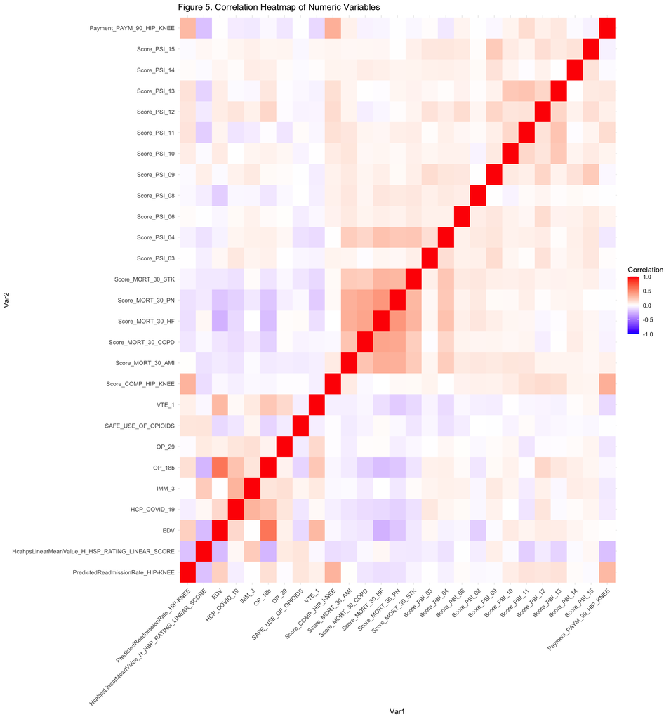

```r
# Compute correlation matrix
cor_matrix <- cor(HipKneeTest %>% select_if(is.numeric), use = "pairwise.complete.obs")

# Melt the correlation matrix into a long format
cor_melted <- melt(cor_matrix)

# Plot heatmap
ggplot(cor_melted, aes(x = Var1, y = Var2, fill = value)) +
  geom_tile() +
  scale_fill_gradient2(low = "blue", high = "red", mid = "white",
                       midpoint = 0, limit = c(-1, 1), name = "Correlation") +
  theme_minimal() +
  theme(axis.text.x = element_text(angle = 45, hjust = 1)) +
  labs(title = "Figure 5. Correlation Heatmap of Numeric Variables")
```

```r
# Convert correlation matrix to df
cor_table <- as.data.frame(cor_matrix)

# Add variable names as a column
cor_table$Variable <- rownames(cor_table)

# Reorder columns
cor_table <- cor_table %>%
  select(Variable, everything())

# Print table
cor_table %>%
  kable(caption = "Table 8. Correlation Coefficients Table") %>%
  kable_styling(bootstrap_options = c("hover", "striped", "responsive"))
```

Table 8. Correlation Coefficients Table

|  | Variable | PredictedReadmissionRate_HIP-KNEE | HcahpsLinearMeanValue_H_HSP_RATING_LINEAR_SCORE | EDV | HCP_COVID_19 | IMM_3 | OP_18b | OP_29 | SAFE_USE_OF_OPIOIDS | VTE_1 | Score_COMP_HIP_KNEE | Score_MORT_30_AMI | Score_MORT_30_COPD | Score_MORT_30_HF | Score_MORT_30_PN | Score_MORT_30_STK | Score_PSI_03 | Score_PSI_04 | Score_PSI_06 | Score_PSI_08 | Score_PSI_09 | Score_PSI_10 | Score_PSI_11 | Score_PSI_12 | Score_PSI_13 | Score_PSI_14 | Score_PSI_15 | Payment_PAYM_90_HIP_KNEE |
| --- | --- | --- | --- | --- | --- | --- | --- | --- | --- | --- | --- | --- | --- | --- | --- | --- | --- | --- | --- | --- | --- | --- | --- | --- | --- | --- | --- | --- |
| PredictedReadmissionRate_HIP-KNEE | PredictedReadmissionRate_HIP-KNEE | 1.0000000 | -0.2060912 | 0.1986939 | -0.0563082 | -0.0028840 | 0.1295727 | -0.0106510 | 0.1063002 | 0.0654668 | 0.3208550 | 0.0074065 | -0.0794948 | -0.1067828 | -0.0985660 | -0.0376746 | -0.0037334 | -0.0449077 | 0.0154891 | -0.0214412 | -0.0182303 | 0.0710046 | 0.1130121 | 0.1047402 | 0.1193336 | 0.0140012 | -0.0158282 | 0.2975679 |
| HcahpsLinearMeanValue_H_HSP_RATING_LINEAR_SCORE | HcahpsLinearMeanValue_H_HSP_RATING_LINEAR_SCORE | -0.2060912 | 1.0000000 | -0.2262341 | 0.0302154 | 0.2182505 | -0.2448842 | 0.0865028 | 0.1100002 | -0.0248375 | -0.1091775 | -0.0952111 | -0.0230632 | 0.0300940 | -0.0702915 | -0.0760295 | -0.0499063 | -0.0948401 | -0.0054742 | -0.0590998 | 0.0707774 | -0.0157615 | -0.1615833 | -0.0674588 | -0.1458284 | -0.0172231 | 0.0304634 | -0.2108956 |
| EDV | EDV | 0.1986939 | -0.2262341 | 1.0000000 | 0.1599806 | 0.0038674 | 0.5918897 | 0.0603877 | -0.1223889 | 0.2992859 | -0.0240093 | -0.0687401 | -0.0840621 | -0.2588739 | -0.1904351 | -0.0754281 | 0.0292819 | -0.0438108 | -0.0308989 | -0.1637017 | -0.0181523 | 0.0837980 | 0.0455190 | 0.0749218 | 0.0724936 | 0.0399935 | 0.0144400 | 0.0053946 |
| HCP_COVID_19 | HCP_COVID_19 | -0.0563082 | 0.0302154 | 0.1599806 | 1.0000000 | 0.3203622 | 0.2574291 | 0.1067941 | -0.0812735 | 0.0241622 | -0.0510683 | -0.0869890 | -0.1128278 | -0.1245435 | -0.1523779 | -0.0988833 | 0.0943953 | 0.0417007 | 0.0225916 | -0.0272232 | 0.0549990 | 0.0009222 | -0.0909811 | 0.1091949 | -0.0160408 | 0.0169512 | 0.0430812 | -0.0627505 |
| IMM_3 | IMM_3 | -0.0028840 | 0.2182505 | 0.0038674 | 0.3203622 | 1.0000000 | 0.1105628 | 0.1317922 | 0.0410289 | 0.0906329 | -0.0212916 | -0.0165321 | -0.0616051 | -0.0010634 | -0.0761104 | 0.0146397 | 0.0451508 | 0.0601831 | 0.0544576 | -0.0311579 | 0.0899361 | 0.0412713 | -0.0625676 | 0.0594933 | -0.0250714 | 0.0723872 | 0.0625753 | -0.0720431 |
| OP_18b | OP_18b | 0.1295727 | -0.2448842 | 0.5918897 | 0.2574291 | 0.1105628 | 1.0000000 | 0.0506067 | -0.1400845 | 0.2344307 | -0.0293698 | -0.0678837 | -0.1527290 | -0.2195933 | -0.1858291 | -0.0905644 | 0.0583644 | 0.0638412 | 0.0187794 | -0.0806516 | 0.0224833 | 0.0544528 | -0.0076797 | 0.1653812 | 0.0993570 | 0.0676972 | 0.0374530 | -0.0241965 |
| OP_29 | OP_29 | -0.0106510 | 0.0865028 | 0.0603877 | 0.1067941 | 0.1317922 | 0.0506067 | 1.0000000 | -0.0650231 | 0.1567526 | -0.0096464 | -0.0600569 | 0.0081252 | 0.0099705 | -0.0536184 | -0.0251654 | -0.0032584 | 0.0312780 | 0.0059688 | -0.0199006 | 0.0150699 | 0.0331569 | -0.0837910 | -0.0108546 | -0.0087678 | 0.0163779 | 0.0419068 | -0.0815209 |
| SAFE_USE_OF_OPIOIDS | SAFE_USE_OF_OPIOIDS | 0.1063002 | 0.1100002 | -0.1223889 | -0.0812735 | 0.0410289 | -0.1400845 | -0.0650231 | 1.0000000 | -0.0563373 | -0.0081923 | -0.0643353 | -0.0362573 | 0.0171605 | -0.0204107 | -0.0804707 | -0.0287158 | -0.0995591 | -0.0603629 | -0.0017558 | -0.0043396 | -0.0382369 | 0.0137283 | -0.0380145 | -0.0258097 | -0.0166146 | -0.0268805 | -0.0048449 |
| VTE_1 | VTE_1 | 0.0654668 | -0.0248375 | 0.2992859 | 0.0241622 | 0.0906329 | 0.2344307 | 0.1567526 | -0.0563373 | 1.0000000 | -0.0526925 | -0.0493931 | -0.0282911 | -0.1051171 | -0.1710235 | -0.1238916 | -0.0378500 | -0.1180160 | -0.0262166 | -0.0522876 | -0.0577213 | -0.0037803 | -0.0301775 | -0.0317534 | -0.0440578 | 0.0086141 | 0.0326658 | -0.1256363 |
| Score_COMP_HIP_KNEE | Score_COMP_HIP_KNEE | 0.3208550 | -0.1091775 | -0.0240093 | -0.0510683 | -0.0212916 | -0.0293698 | -0.0096464 | -0.0081923 | -0.0526925 | 1.0000000 | 0.0830479 | -0.0203930 | -0.0007242 | 0.0241066 | 0.0211621 | 0.0498557 | 0.0038509 | 0.0505415 | 0.0577776 | 0.0540124 | 0.0813038 | 0.1279724 | 0.1458258 | 0.1334619 | 0.0498603 | 0.0433809 | 0.3410864 |
| Score_MORT_30_AMI | Score_MORT_30_AMI | 0.0074065 | -0.0952111 | -0.0687401 | -0.0869890 | -0.0165321 | -0.0678837 | -0.0600569 | -0.0643353 | -0.0493931 | 0.0830479 | 1.0000000 | 0.2498600 | 0.3407616 | 0.3309425 | 0.2222539 | 0.0415523 | 0.2105379 | 0.0885083 | 0.1010348 | 0.0889343 | 0.1066619 | 0.1037006 | 0.0492328 | 0.0467554 | 0.0454462 | 0.0297688 | 0.0591548 |
| Score_MORT_30_COPD | Score_MORT_30_COPD | -0.0794948 | -0.0230632 | -0.0840621 | -0.1128278 | -0.0616051 | -0.1527290 | 0.0081252 | -0.0362573 | -0.0282911 | -0.0203930 | 0.2498600 | 1.0000000 | 0.3844105 | 0.3710744 | 0.2038243 | -0.0069743 | 0.1713379 | 0.0478268 | 0.0397571 | 0.0429090 | 0.0320669 | 0.0426574 | -0.0532586 | 0.0026944 | 0.0734846 | 0.0340007 | -0.0406696 |
| Score_MORT_30_HF | Score_MORT_30_HF | -0.1067828 | 0.0300940 | -0.2588739 | -0.1245435 | -0.0010634 | -0.2195933 | 0.0099705 | 0.0171605 | -0.1051171 | -0.0007242 | 0.3407616 | 0.3844105 | 1.0000000 | 0.4479367 | 0.3147371 | 0.0371596 | 0.2556384 | 0.0679149 | 0.1051698 | 0.0707269 | 0.0383771 | 0.0362529 | -0.0300702 | -0.0086832 | 0.0647245 | 0.0342374 | -0.0350247 |
| Score_MORT_30_PN | Score_MORT_30_PN | -0.0985660 | -0.0702915 | -0.1904351 | -0.1523779 | -0.0761104 | -0.1858291 | -0.0536184 | -0.0204107 | -0.1710235 | 0.0241066 | 0.3309425 | 0.3710744 | 0.4479367 | 1.0000000 | 0.3042563 | 0.0303815 | 0.2301195 | 0.0543554 | 0.0884315 | 0.0217880 | 0.0237048 | 0.0704445 | 0.0089560 | 0.0393676 | 0.0464407 | 0.0029691 | -0.0062985 |
| Score_MORT_30_STK | Score_MORT_30_STK | -0.0376746 | -0.0760295 | -0.0754281 | -0.0988833 | 0.0146397 | -0.0905644 | -0.0251654 | -0.0804707 | -0.1238916 | 0.0211621 | 0.2222539 | 0.2038243 | 0.3147371 | 0.3042563 | 1.0000000 | 0.0687216 | 0.2380935 | 0.0878847 | 0.1014879 | 0.0674377 | 0.0622532 | 0.0725381 | 0.0474896 | 0.0513975 | 0.0492194 | 0.0625191 | -0.0272101 |
| Score_PSI_03 | Score_PSI_03 | -0.0037334 | -0.0499063 | 0.0292819 | 0.0943953 | 0.0451508 | 0.0583644 | -0.0032584 | -0.0287158 | -0.0378500 | 0.0498557 | 0.0415523 | -0.0069743 | 0.0371596 | 0.0303815 | 0.0687216 | 1.0000000 | 0.1353085 | 0.0601750 | 0.0636661 | 0.1407342 | 0.0386211 | 0.0114365 | 0.1186788 | 0.0298580 | 0.0596798 | 0.0999683 | 0.0086745 |
| Score_PSI_04 | Score_PSI_04 | -0.0449077 | -0.0948401 | -0.0438108 | 0.0417007 | 0.0601831 | 0.0638412 | 0.0312780 | -0.0995591 | -0.1180160 | 0.0038509 | 0.2105379 | 0.1713379 | 0.2556384 | 0.2301195 | 0.2380935 | 0.1353085 | 1.0000000 | 0.0601419 | 0.0870693 | 0.1059485 | 0.0523892 | 0.0649032 | 0.0782559 | 0.0123489 | 0.0652098 | 0.1018205 | -0.0766302 |
| Score_PSI_06 | Score_PSI_06 | 0.0154891 | -0.0054742 | -0.0308989 | 0.0225916 | 0.0544576 | 0.0187794 | 0.0059688 | -0.0603629 | -0.0262166 | 0.0505415 | 0.0885083 | 0.0478268 | 0.0679149 | 0.0543554 | 0.0878847 | 0.0601750 | 0.0601419 | 1.0000000 | 0.0724291 | 0.1014588 | 0.0516246 | 0.0351464 | 0.1431056 | 0.0509831 | 0.0527115 | 0.0910520 | 0.0456525 |
| Score_PSI_08 | Score_PSI_08 | -0.0214412 | -0.0590998 | -0.1637017 | -0.0272232 | -0.0311579 | -0.0806516 | -0.0199006 | -0.0017558 | -0.0522876 | 0.0577776 | 0.1010348 | 0.0397571 | 0.1051698 | 0.0884315 | 0.1014879 | 0.0636661 | 0.0870693 | 0.0724291 | 1.0000000 | 0.0052449 | -0.0360093 | 0.0198090 | 0.0394605 | 0.0093444 | 0.0228045 | 0.0127268 | -0.0041983 |
| Score_PSI_09 | Score_PSI_09 | -0.0182303 | 0.0707774 | -0.0181523 | 0.0549990 | 0.0899361 | 0.0224833 | 0.0150699 | -0.0043396 | -0.0577213 | 0.0540124 | 0.0889343 | 0.0429090 | 0.0707269 | 0.0217880 | 0.0674377 | 0.1407342 | 0.1059485 | 0.1014588 | 0.0052449 | 1.0000000 | 0.0885278 | 0.0680540 | 0.1732337 | 0.0519119 | 0.1207438 | 0.2197254 | -0.0237660 |
| Score_PSI_10 | Score_PSI_10 | 0.0710046 | -0.0157615 | 0.0837980 | 0.0009222 | 0.0412713 | 0.0544528 | 0.0331569 | -0.0382369 | -0.0037803 | 0.0813038 | 0.1066619 | 0.0320669 | 0.0383771 | 0.0237048 | 0.0622532 | 0.0386211 | 0.0523892 | 0.0516246 | -0.0360093 | 0.0885278 | 1.0000000 | 0.1626632 | 0.1079488 | 0.2303938 | 0.0453739 | 0.0830134 | 0.0497447 |
| Score_PSI_11 | Score_PSI_11 | 0.1130121 | -0.1615833 | 0.0455190 | -0.0909811 | -0.0625676 | -0.0076797 | -0.0837910 | 0.0137283 | -0.0301775 | 0.1279724 | 0.1037006 | 0.0426574 | 0.0362529 | 0.0704445 | 0.0725381 | 0.0114365 | 0.0649032 | 0.0351464 | 0.0198090 | 0.0680540 | 0.1626632 | 1.0000000 | 0.1172504 | 0.2506376 | -0.0093577 | 0.0464067 | 0.1441986 |
| Score_PSI_12 | Score_PSI_12 | 0.1047402 | -0.0674588 | 0.0749218 | 0.1091949 | 0.0594933 | 0.1653812 | -0.0108546 | -0.0380145 | -0.0317534 | 0.1458258 | 0.0492328 | -0.0532586 | -0.0300702 | 0.0089560 | 0.0474896 | 0.1186788 | 0.0782559 | 0.1431056 | 0.0394605 | 0.1732337 | 0.1079488 | 0.1172504 | 1.0000000 | 0.1742084 | 0.0522204 | 0.1358951 | 0.0655557 |
| Score_PSI_13 | Score_PSI_13 | 0.1193336 | -0.1458284 | 0.0724936 | -0.0160408 | -0.0250714 | 0.0993570 | -0.0087678 | -0.0258097 | -0.0440578 | 0.1334619 | 0.0467554 | 0.0026944 | -0.0086832 | 0.0393676 | 0.0513975 | 0.0298580 | 0.0123489 | 0.0509831 | 0.0093444 | 0.0519119 | 0.2303938 | 0.2506376 | 0.1742084 | 1.0000000 | 0.0056987 | 0.0878105 | 0.0949467 |
| Score_PSI_14 | Score_PSI_14 | 0.0140012 | -0.0172231 | 0.0399935 | 0.0169512 | 0.0723872 | 0.0676972 | 0.0163779 | -0.0166146 | 0.0086141 | 0.0498603 | 0.0454462 | 0.0734846 | 0.0647245 | 0.0464407 | 0.0492194 | 0.0596798 | 0.0652098 | 0.0527115 | 0.0228045 | 0.1207438 | 0.0453739 | -0.0093577 | 0.0522204 | 0.0056987 | 1.0000000 | 0.1176726 | -0.0181150 |
| Score_PSI_15 | Score_PSI_15 | -0.0158282 | 0.0304634 | 0.0144400 | 0.0430812 | 0.0625753 | 0.0374530 | 0.0419068 | -0.0268805 | 0.0326658 | 0.0433809 | 0.0297688 | 0.0340007 | 0.0342374 | 0.0029691 | 0.0625191 | 0.0999683 | 0.1018205 | 0.0910520 | 0.0127268 | 0.2197254 | 0.0830134 | 0.0464067 | 0.1358951 | 0.0878105 | 0.1176726 | 1.0000000 | -0.0467071 |
| Payment_PAYM_90_HIP_KNEE | Payment_PAYM_90_HIP_KNEE | 0.2975679 | -0.2108956 | 0.0053946 | -0.0627505 | -0.0720431 | -0.0241965 | -0.0815209 | -0.0048449 | -0.1256363 | 0.3410864 | 0.0591548 | -0.0406696 | -0.0350247 | -0.0062985 | -0.0272101 | 0.0086745 | -0.0766302 | 0.0456525 | -0.0041983 | -0.0237660 | 0.0497447 | 0.1441986 | 0.0655557 | 0.0949467 | -0.0181150 | -0.0467071 | 1.0000000 |

### Imputation and Handling of Missing Values

```r
# Change - to _ in HIP-KNEE
colnames(HipKneeTest) <- gsub("-", "_", colnames(HipKneeTest))

# Remove all NA values in target variable "PredictedReadmissionRate_HIP_KNEE"
HipKneeTest <- HipKneeTest %>% filter(!is.na(PredictedReadmissionRate_HIP_KNEE))

# Remove all NA values in the "State", "StateCode", and "FacilityName" columns
HipKneeTest <- HipKneeTest %>% drop_na(State, StateCode, FacilityName)


# Print number of remaining variables and observations
dimensions <- dim(HipKneeTest)
cat("Number of variables:", dimensions[2], "\n")
```

```
## Number of variables: 31
```

```r
cat("Number of observations:", dimensions[1], "\n")
```

```
## Number of observations: 1833
```

```r
# Calculate missing values
missing_values_summary <- HipKneeTest %>%
  summarise(across(everything(), ~ sum(is.na(.)))) %>%
  pivot_longer(cols = everything(), names_to = "Variable", values_to = "Missing_Count") %>%
  mutate(Missing_Percentage = (Missing_Count / nrow(HipKneeTest)) * 100)

# Print table
missing_values_summary %>%
  kable(caption = "Table 7. Missing Values Summary") %>%
  kable_styling(bootstrap_options = c("hover", "striped", "responsive"))
```

Table 7. Missing Values Summary

| Variable | Missing_Count | Missing_Percentage |
| --- | --- | --- |
| FacilityId | 0 | 0.0000000 |
| PredictedReadmissionRate_HIP_KNEE | 0 | 0.0000000 |
| HcahpsLinearMeanValue_H_HSP_RATING_LINEAR_SCORE | 33 | 1.8003273 |
| EDV | 90 | 4.9099836 |
| HCP_COVID_19 | 16 | 0.8728860 |
| IMM_3 | 16 | 0.8728860 |
| OP_18b | 75 | 4.0916530 |
| OP_29 | 222 | 12.1112930 |
| SAFE_USE_OF_OPIOIDS | 69 | 3.7643208 |
| VTE_1 | 994 | 54.2280415 |
| Score_COMP_HIP_KNEE | 40 | 2.1822149 |
| Score_MORT_30_AMI | 405 | 22.0949264 |
| Score_MORT_30_COPD | 247 | 13.4751773 |
| Score_MORT_30_HF | 141 | 7.6923077 |
| Score_MORT_30_PN | 125 | 6.8194217 |
| Score_MORT_30_STK | 284 | 15.4937261 |
| Score_PSI_03 | 8 | 0.4364430 |
| Score_PSI_04 | 575 | 31.3693399 |
| Score_PSI_06 | 2 | 0.1091107 |
| Score_PSI_08 | 2 | 0.1091107 |
| Score_PSI_09 | 2 | 0.1091107 |
| Score_PSI_10 | 41 | 2.2367703 |
| Score_PSI_11 | 40 | 2.1822149 |
| Score_PSI_12 | 2 | 0.1091107 |
| Score_PSI_13 | 42 | 2.2913257 |
| Score_PSI_14 | 87 | 4.7463175 |
| Score_PSI_15 | 29 | 1.5821058 |
| FacilityName | 0 | 0.0000000 |
| State | 0 | 0.0000000 |
| Payment_PAYM_90_HIP_KNEE | 42 | 2.2913257 |
| StateCode | 0 | 0.0000000 |

#### Impute variables with low percentage missingness (<5%) by the median for numeric variables and mode for categorical variables

```r
# Calculate median for columns with <5% missing values
numeric_vars_low_missing <- c("HcahpsLinearMeanValue_H_HSP_RATING_LINEAR_SCORE", "EDV", "HCP_COVID_19", "IMM_3", "OP_18b", "SAFE_USE_OF_OPIOIDS", "Score_COMP_HIP_KNEE", "Score_PSI_03", "Score_PSI_06", "Score_PSI_08", "Score_PSI_09", "Score_PSI_10", "Score_PSI_11", "Score_PSI_12", "Score_PSI_13", "Score_PSI_14", "Score_PSI_15", "Payment_PAYM_90_HIP_KNEE")

for (var in numeric_vars_low_missing) {
  HipKneeTest[[var]][is.na(HipKneeTest[[var]])] <- median(HipKneeTest[[var]], na.rm = TRUE)
}
```

#### Impute high percentage missingness variables (>5%) using KNN

```r
# Select high missingness variables for KNN imputation
vars_for_knn <- c("VTE_1", "Score_MORT_30_AMI", "Score_MORT_30_COPD", "Score_MORT_30_HF", "Score_MORT_30_PN", "Score_MORT_30_STK", "Score_PSI_04", "OP_29")

# Perform KNN imputation
HipKneeTest_knn <- kNN(HipKneeTest, variable = vars_for_knn, k = 5)

# Remove columns created by the KNN function
HipKneeTest_knn <- HipKneeTest_knn %>% select(-ends_with("_imp"))

# Update HipKneeTrain with imputed values
HipKneeTest[vars_for_knn] <- HipKneeTest_knn[vars_for_knn]
```

```r
# Calculate missing values
missing_values_summary <- HipKneeTest %>%
  summarise(across(everything(), ~ sum(is.na(.)))) %>%
  pivot_longer(cols = everything(), names_to = "Variable", values_to = "Missing_Count") %>%
  mutate(Missing_Percentage = (Missing_Count / nrow(HipKneeTest)) * 100)

# Print table
missing_values_summary %>%
  kable(caption = "Table 7. Missing Values Summary") %>%
  kable_styling(bootstrap_options = c("hover", "striped", "responsive"))
```

Table 7. Missing Values Summary

| Variable | Missing_Count | Missing_Percentage |
| --- | --- | --- |
| FacilityId | 0 | 0 |
| PredictedReadmissionRate_HIP_KNEE | 0 | 0 |
| HcahpsLinearMeanValue_H_HSP_RATING_LINEAR_SCORE | 0 | 0 |
| EDV | 0 | 0 |
| HCP_COVID_19 | 0 | 0 |
| IMM_3 | 0 | 0 |
| OP_18b | 0 | 0 |
| OP_29 | 0 | 0 |
| SAFE_USE_OF_OPIOIDS | 0 | 0 |
| VTE_1 | 0 | 0 |
| Score_COMP_HIP_KNEE | 0 | 0 |
| Score_MORT_30_AMI | 0 | 0 |
| Score_MORT_30_COPD | 0 | 0 |
| Score_MORT_30_HF | 0 | 0 |
| Score_MORT_30_PN | 0 | 0 |
| Score_MORT_30_STK | 0 | 0 |
| Score_PSI_03 | 0 | 0 |
| Score_PSI_04 | 0 | 0 |
| Score_PSI_06 | 0 | 0 |
| Score_PSI_08 | 0 | 0 |
| Score_PSI_09 | 0 | 0 |
| Score_PSI_10 | 0 | 0 |
| Score_PSI_11 | 0 | 0 |
| Score_PSI_12 | 0 | 0 |
| Score_PSI_13 | 0 | 0 |
| Score_PSI_14 | 0 | 0 |
| Score_PSI_15 | 0 | 0 |
| FacilityName | 0 | 0 |
| State | 0 | 0 |
| Payment_PAYM_90_HIP_KNEE | 0 | 0 |
| StateCode | 0 | 0 |